# Predicting NBA Salary

Ben Stano, Addy Lai, Prav Mahadevan, Nick Oggero

2/16/2022

# Predicting NBA Salary

We will evaluate the key aspects of player NBA performance that can be used to predict salary. We will accomplish this by modeling player salary.

# Importing Data

Our data has been source from Kaggle and can be found (here)[https://www.kaggle.com/adityak2003/college-basketball-players-20092021]

```r
# players <- read_csv("../data/players.csv")
# stats.36 <- read_csv("../data/PlayerStatisticsPer36Min.csv")
# stats.100 <- read_csv("../data/PlayerStatisticsPer100Poss.csv")
# stats.g <- read_csv("../data/PlayerStatisticsPerGame.csv")
# # salary <- read_csv("../data/salaries_1985to2018.csv")
# salary2 <- read_csv("../data/nba-salaries.csv")
```

# Cleaning and Merging Data

The data was in separate tables. These tables need to be merged and formatted correctly

```r
library(tidyverse)
# stats.g <- stats.g %>%
#   mutate(name = str_replace(Player, "\\*", ""))
# stats.g <- stats.g %>%
#   mutate(key = str_c(name, as.character(year), sep = ""))
# salary2 <- salary2 %>%
#   mutate(key = str_c(name, as.character(season), sep = ""))
```

## Joining the Datasets

```r
# final.data <- players %>%
#   inner_join(salary2, by = "name") %>%
#   inner_join(stats.g, by = "key") %>%
#   select(-key) %>%
#   filter(year >= 2017)
#
# write_csv(final.data, "../data/final_data.csv")

bdata.raw <- read_csv("../data/final_data.csv")
```

## Cleaning the Data

```r
bdata.raw <- read_csv("../data/final_data.csv")
```

```r
# displaying null values in each column
bdata.raw %>%
  map_dbl(~sum(is.na(.))) %>%
  unname() ->
na.dbl

na.cols <- data.frame("variable" = colnames(bdata.raw),
                      "null.count" = na.dbl)

na.cols %>%
  filter(null.count > 0)
```

```
##       variable null.count
## 1      college        246
## 2   draft_pick        354
## 3  draft_round        354
## 4   draft_team        354
## 5   draft_year        354
## 6   highSchool        178
## 7          FG%          5
## 8          3P%        123
## 9          2P%         20
## 10        eFG%          5
## 11         FT%         74
```

```r
# parsing numbers from difficult columns
bdata.raw$career_FG3_P <- parse_number(as.character(bdata.raw$`career_FG3%`))
bdata.raw$career_FG_P <- parse_number(as.character(bdata.raw$`career_FG%`))
bdata.raw$career_FT_P <- parse_number(as.character(bdata.raw$`career_FT%`))
# cleaning height
heights <- str_split(bdata.raw$height, "\\-")
heights.df <- t(data.frame(heights))
heights.int <- as.integer(heights.df[,1]) * 12 + as.integer(heights.df[,2])
bdata.raw$height <- heights.int

bdata.raw %>%
  mutate(draft_pick = parse_number(draft_pick),
         draft_round = parse_number(draft_round),
         shoots_right = ifelse(str_detect(shoots, "Right"),1,0),
         weight = parse_number(weight),
         Pos = as.factor(Pos)) %>%
  rename(career_eFG_P = `career_eFG%`,
         FG_P = `FG%`,
         THREEP_P = `3P%`,
         THREEP = `3P`,
         THREEP_A = `3PA`,
         TWOP_P = `2P%`,
         TWOP = `2P`,
         TWOP_A = `2PA`,
         eFG_P = `eFG%`,
         FT_P = `FT%`) %>%
  select(-birthDate, -birthPlace, -college, -draft_team, -highSchool, -name.x,
         -position.x, -position.y, -team, -Player, -name.y, -season, -Tm,
         # rank removed
         -`career_FG3%`, -`career_FG%`, -`career_FT%`, -shoots, -rank) %>%
  na.omit() ->
bdata.clean

bdata.clean %>%
  select(-`_id`) ->
bdata.model
```

We chose not to use rank as a predictor, even though it has mostly non-NA values. A given player rank is essentially the same as what we are trying to predict, so using it would bias our results.

# Transforming the Response Variable

```r
ols.init <- lm(salary ~ ., data = bdata.model)

summary(ols.init)
```

```
##
## Call:
## lm(formula = salary ~ ., data = bdata.model)
##
## Residuals:
##       Min        1Q    Median        3Q       Max
## -20622532  -3122535    -91646   2941145  19302908
##
## Coefficients:
##                Estimate Std. Error t value Pr(>|t|)
## (Intercept)  -1.632e+09  3.201e+08  -5.098 3.89e-07 ***
## career_AST   -3.513e+05  2.776e+05  -1.266  0.20581
## career_G      4.454e+02  1.811e+03   0.246  0.80577
## career_PER   -4.135e+04  1.322e+05  -0.313  0.75448
## career_PTS    2.234e+04  1.115e+05   0.200  0.84129
## career_TRB    2.181e+05  2.202e+05   0.991  0.32206
## career_WS     7.368e+04  1.210e+04   6.090 1.44e-09 ***
## career_eFG_P  2.623e+04  1.067e+05   0.246  0.80581
## draft_pick   -7.459e+03  2.106e+04  -0.354  0.72323
## draft_round   6.839e+04  6.155e+05   0.111  0.91154
## draft_year   -1.748e+05  8.992e+04  -1.944  0.05213 .
## height        1.899e+05  1.032e+05   1.841  0.06589 .
## weight        1.227e+04  1.238e+04   0.991  0.32185
## PosC-PF      -5.817e+05  2.817e+06  -0.207  0.83641
## PosPF         4.941e+05  6.184e+05   0.799  0.42439
## PosPF-C       4.668e+05  5.585e+06   0.084  0.93340
## PosPF-SF      3.979e+06  3.284e+06   1.212  0.22582
## PosPG         9.371e+05  1.199e+06   0.781  0.43474
## PosPG-SG     -2.693e+06  5.729e+06  -0.470  0.63833
## PosSF         2.024e+05  8.366e+05   0.242  0.80884
## PosSF-PF      2.665e+06  5.693e+06   0.468  0.63979
## PosSF-SG      5.998e+06  3.326e+06   1.804  0.07150 .
## PosSG         1.028e+06  9.994e+05   1.029  0.30374
## PosSG-PF     -2.442e+06  5.648e+06  -0.432  0.66551
## Age          -5.277e+04  1.058e+05  -0.499  0.61801
## G            -2.246e+04  8.621e+03  -2.606  0.00926 **
## GS            4.188e+04  9.599e+03   4.362 1.38e-05 ***
## MP            3.896e+04  6.618e+04   0.589  0.55617
## FG            8.125e+06  4.465e+06   1.820  0.06898 .
## FGA           2.786e+06  2.913e+06   0.956  0.33913
```

[output cut: 16 more lines]

```
## BLK           4.159e+05  5.645e+05   0.737  0.46131
## TOV           2.149e+05  5.391e+05   0.399  0.69023
## PF           -1.581e+06  3.519e+05  -4.491 7.65e-06 ***
## PTS          -3.425e+06  1.955e+06  -1.752  0.08004 .
## year          9.743e+05  1.720e+05   5.665 1.77e-08 ***
## career_FG3_P  4.840e+04  3.171e+04   1.526  0.12715
## career_FG_P   3.872e+04  1.188e+05   0.326  0.74447
## career_FT_P   2.116e+04  2.484e+04   0.852  0.39446
## shoots_right  1.222e+06  5.576e+05   2.191  0.02864 *
## ---
## Signif. codes:  0 '***' 0.001 '**' 0.01 '*' 0.05 '.' 0.1 ' ' 1
##
## Residual standard error: 5522000 on 1445 degrees of freedom
## Multiple R-squared:  0.561,  Adjusted R-squared:  0.5446
## F-statistic:  34.2 on 54 and 1445 DF,  p-value: < 2.2e-16
```

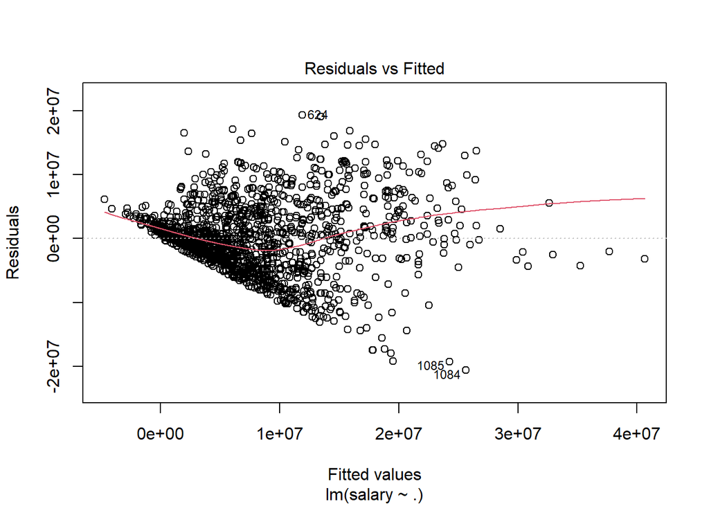

```r
plot(ols.init, which = 1)
```

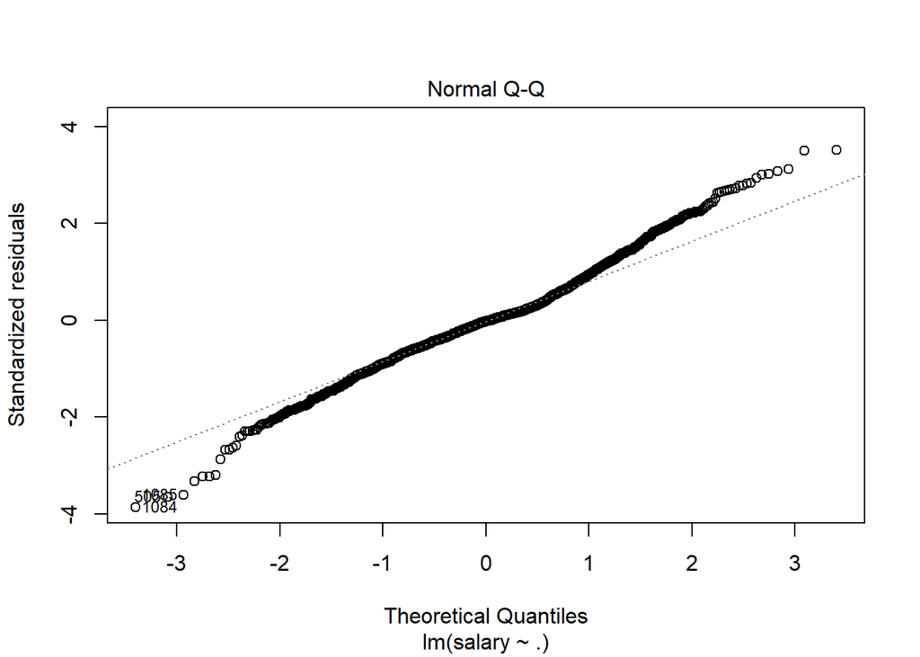

```r
plot(ols.init, which = 2)
```

The relationship between the response, salary, and the predictors is clearly curved. To remedy this, we will log-transform salary.

```r
bdata.model %>%
  mutate(log_salary = log(salary)) ->
bdata.log

bdata.log$salary <- NULL
```

```r
ols.log0 <- lm(log_salary ~ ., data = bdata.log)

summary(ols.log0)
```

```
##
## Call:
## lm(formula = log_salary ~ ., data = bdata.log)
##
## Residuals:
##     Min      1Q  Median      3Q     Max
## -5.7116 -0.4816  0.1098  0.6266  2.1264
##
## Coefficients:
##                Estimate Std. Error t value Pr(>|t|)
## (Intercept)  -3.383e+02  5.578e+01  -6.065 1.68e-09 ***
## career_AST   -3.835e-02  4.836e-02  -0.793  0.42793
## career_G      1.317e-03  3.155e-04   4.175 3.16e-05 ***
## career_PER    1.882e-02  2.303e-02   0.817  0.41387
## career_PTS   -2.531e-02  1.943e-02  -1.302  0.19307
## career_TRB    3.150e-02  3.836e-02   0.821  0.41178
## career_WS     4.361e-05  2.108e-03   0.021  0.98350
## career_eFG_P  2.260e-02  1.859e-02   1.216  0.22427
## draft_pick   -3.496e-03  3.669e-03  -0.953  0.34078
## draft_round   5.346e-02  1.072e-01   0.499  0.61820
## draft_year   -3.388e-02  1.567e-02  -2.163  0.03072 *
## height        3.862e-02  1.798e-02   2.148  0.03185 *
## weight        1.282e-05  2.157e-03   0.006  0.99526
## PosC-PF       1.002e-01  4.908e-01   0.204  0.83822
## PosPF        -8.763e-03  1.077e-01  -0.081  0.93519
## PosPF-C      -9.330e-02  9.731e-01  -0.096  0.92363
## PosPF-SF      1.285e-03  5.722e-01   0.002  0.99821
## PosPG        -2.401e-02  2.090e-01  -0.115  0.90856
## PosPG-SG     -6.568e-01  9.982e-01  -0.658  0.51061
## PosSF        -5.776e-02  1.458e-01  -0.396  0.69198
## PosSF-PF      6.017e-01  9.918e-01   0.607  0.54416
## PosSF-SG      5.506e-01  5.795e-01   0.950  0.34220
## PosSG         8.647e-04  1.741e-01   0.005  0.99604
## PosSG-PF     -2.804e-01  9.841e-01  -0.285  0.77571
## Age          -5.501e-02  1.844e-02  -2.984  0.00289 **
## G             3.814e-03  1.502e-03   2.539  0.01121 *
## GS            5.216e-03  1.673e-03   3.119  0.00185 **
## MP            2.496e-02  1.153e-02   2.165  0.03057 *
## FG            1.410e+00  7.779e-01   1.812  0.07020 .
## FGA           2.407e-01  5.076e-01   0.474  0.63543
```

[output cut: 16 more lines]

```
## BLK           9.654e-02  9.835e-02   0.982  0.32647
## TOV           2.215e-01  9.393e-02   2.358  0.01853 *
## PF           -1.835e-01  6.132e-02  -2.993  0.00281 **
## PTS          -7.396e-01  3.407e-01  -2.171  0.03011 *
## year          2.068e-01  2.996e-02   6.901 7.68e-12 ***
## career_FG3_P  1.475e-02  5.525e-03   2.669  0.00770 **
## career_FG_P  -5.584e-03  2.069e-02  -0.270  0.78733
## career_FT_P   6.078e-03  4.327e-03   1.405  0.16037
## shoots_right  7.202e-02  9.716e-02   0.741  0.45863
## ---
## Signif. codes:  0 '***' 0.001 '**' 0.01 '*' 0.05 '.' 0.1 ' ' 1
##
## Residual standard error: 0.9621 on 1445 degrees of freedom
## Multiple R-squared:  0.4338, Adjusted R-squared:  0.4126
## F-statistic:  20.5 on 54 and 1445 DF,  p-value: < 2.2e-16
```

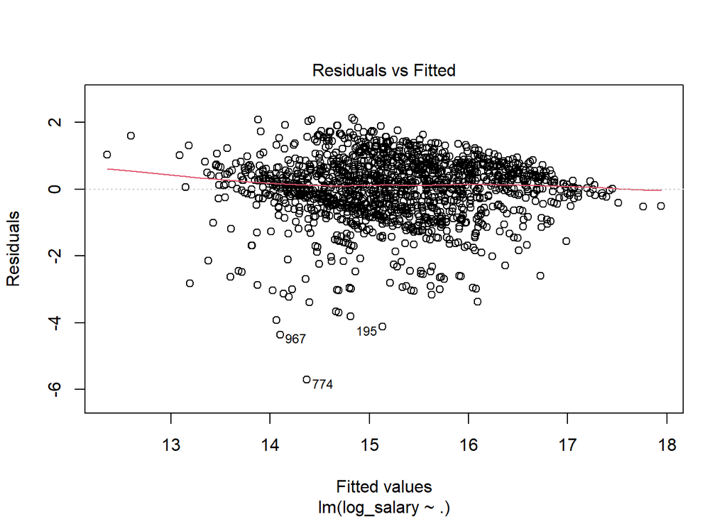

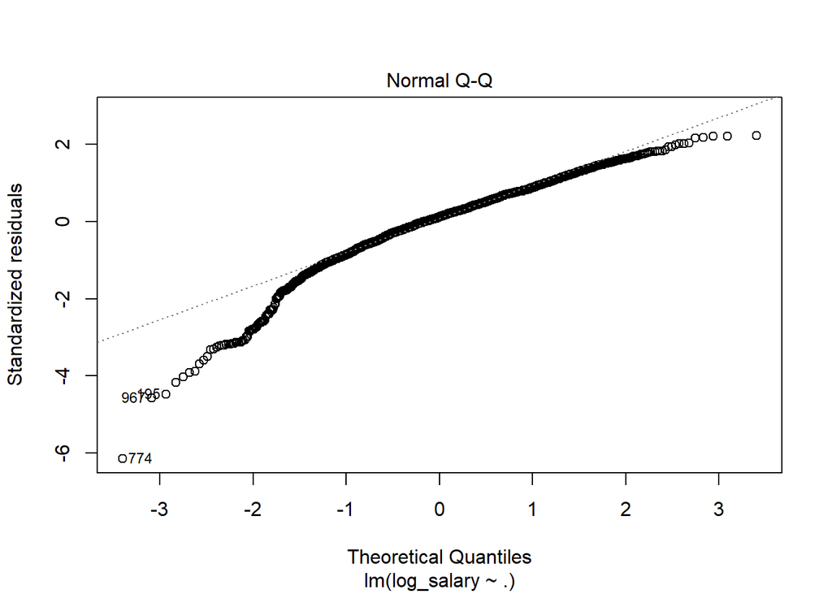

```r
plot(ols.log0, which = c(1, 2))
```

```r
library(car)
vif(ols.log0)
```

```
##                     GVIF Df GVIF^(1/(2*Df))
## career_AST     10.510720  1        3.242024
## career_G       14.466071  1        3.803429
## career_PER     13.799605  1        3.714782
## career_PTS     15.258214  1        3.906176
## career_TRB     11.344147  1        3.368107
## career_WS       6.650021  1        2.578763
## career_eFG_P   10.961746  1        3.310853
## draft_pick      5.196108  1        2.279497
## draft_round     4.379880  1        2.092816
## draft_year      8.864291  1        2.977296
## height          5.683700  1        2.384051
## weight          4.213555  1        2.052694
## Pos            26.385107 11        1.160399
## Age            10.264888  1        3.203886
## G               1.912499  1        1.382931
## GS              3.441360  1        1.855090
## MP             14.795398  1        3.846479
## FG           4737.504961  1       68.829536
## FGA          8877.531050  1       94.220651
## FG_P           41.862346  1        6.470112
## THREEP        535.180030  1       23.133958
## THREEP_A     1866.695078  1       43.205267
## THREEP_P        2.815575  1        1.677968
## TWOP         1602.365789  1       40.029561
## TWOP_A       5038.264908  1       70.980736
## TWOP_P          6.298730  1        2.509727
## eFG_P          28.223485  1        5.312578
## FT            457.356203  1       21.385888
## FTA            88.100489  1        9.386186
## FT_P            2.540489  1        1.593891
## ORB           247.284639  1       15.725287
## DRB          1396.443827  1       37.369022
## TRB          2473.724218  1       49.736548
## AST            11.988090  1        3.462382
## STL             2.772151  1        1.664978
## BLK             2.547507  1        1.596091
## TOV             9.731679  1        3.119564
## PF              3.021412  1        1.738221
## PTS          7179.873637  1       84.734135
## year            1.793255  1        1.339125
## career_FG3_P    3.459448  1        1.859959
## career_FG_P    19.686205  1        4.436914
## career_FT_P     2.685371  1        1.638710
## shoots_right    1.091468  1        1.044733
```

# Feature Selection and Outlier Removal

The data set contains too many features and as such is suffering dimensional issues. Additionally, outliers have skewed our results made our model far too Heteroscedastic.

## Removing Outliers using `outlierTest()`

We can remove the worst ourliers by idenfiying them with the `outlierTest()` function.

```r
outlierTest(ols.log0)
```

```
##      rstudent unadjusted p-value Bonferroni p
## 774 -6.226472         6.2415e-10   9.3498e-07
## 967 -4.601618         4.5597e-06   6.8304e-03
## 195 -4.505044         7.1707e-06   1.0742e-02
## 363 -4.189137         2.9698e-05   4.4487e-02
```

```r
bdata.log.rm <- bdata.log[-c(774, 967, 195, 363),]
```

## Feature Selection Using VIF

On way we can approach dimentionality reduction is by removing features with a high Variance Inflation Factor (VIF).

```r
ols.log <- lm(log_salary ~ ., data = bdata.log.rm)

summary(ols.log)
```

```
##
## Call:
## lm(formula = log_salary ~ ., data = bdata.log.rm)
##
## Residuals:
##     Min      1Q  Median      3Q     Max
## -3.7669 -0.4641  0.0891  0.6127  2.1343
##
## Coefficients:
##                Estimate Std. Error t value Pr(>|t|)
## (Intercept)  -2.943e+02  5.424e+01  -5.425 6.79e-08 ***
## career_AST   -4.530e-02  4.683e-02  -0.967 0.333469
## career_G      1.075e-03  3.067e-04   3.504 0.000473 ***
## career_PER    7.588e-03  2.235e-02   0.339 0.734293
## career_PTS   -2.948e-02  1.883e-02  -1.565 0.117686
## career_TRB    2.692e-02  3.716e-02   0.725 0.468873
## career_WS     4.291e-04  2.040e-03   0.210 0.833405
## career_eFG_P  1.435e-02  1.802e-02   0.797 0.425769
## draft_pick   -4.171e-03  3.553e-03  -1.174 0.240672
## draft_round   5.093e-02  1.039e-01   0.490 0.624064
## draft_year   -3.295e-02  1.516e-02  -2.173 0.029919 *
## height        3.828e-02  1.740e-02   2.200 0.027948 *
## weight       -4.410e-04  2.089e-03  -0.211 0.832809
## PosC-PF       5.397e-02  4.748e-01   0.114 0.909526
## PosPF        -1.254e-02  1.043e-01  -0.120 0.904294
## PosPF-C      -1.349e-01  9.414e-01  -0.143 0.886066
## PosPF-SF      2.780e-02  5.536e-01   0.050 0.959952
## PosPG        -3.632e-02  2.022e-01  -0.180 0.857448
## PosPG-SG     -7.095e-01  9.657e-01  -0.735 0.462651
## PosSF        -3.599e-02  1.411e-01  -0.255 0.798695
## PosSF-PF      4.682e-01  9.600e-01   0.488 0.625815
## PosSF-SG      5.252e-01  5.606e-01   0.937 0.348973
## PosSG         8.624e-03  1.685e-01   0.051 0.959195
## PosSG-PF     -2.435e-01  9.520e-01  -0.256 0.798169
## Age          -3.537e-02  1.799e-02  -1.967 0.049398 *
## G             2.822e-03  1.458e-03   1.935 0.053143 .
## GS            5.290e-03  1.623e-03   3.259 0.001142 **
## MP            2.150e-02  1.117e-02   1.924 0.054553 .
## FG            1.653e+00  7.532e-01   2.195 0.028347 *
## FGA           2.568e-01  4.912e-01   0.523 0.601189
```

[output cut: 16 more lines]

```
## BLK           1.147e-01  9.519e-02   1.205 0.228221
## TOV           2.311e-01  9.110e-02   2.536 0.011310 *
## PF           -2.157e-01  5.950e-02  -3.625 0.000299 ***
## PTS          -8.822e-01  3.301e-01  -2.672 0.007623 **
## year          1.838e-01  2.911e-02   6.313 3.63e-10 ***
## career_FG3_P  1.595e-02  5.366e-03   2.972 0.003006 **
## career_FG_P   7.604e-03  2.008e-02   0.379 0.704931
## career_FT_P   6.763e-03  4.187e-03   1.615 0.106510
## shoots_right  7.728e-02  9.401e-02   0.822 0.411227
## ---
## Signif. codes:  0 '***' 0.001 '**' 0.01 '*' 0.05 '.' 0.1 ' ' 1
##
## Residual standard error: 0.9307 on 1441 degrees of freedom
## Multiple R-squared:  0.4437, Adjusted R-squared:  0.4229
## F-statistic: 21.29 on 54 and 1441 DF,  p-value: < 2.2e-16
```

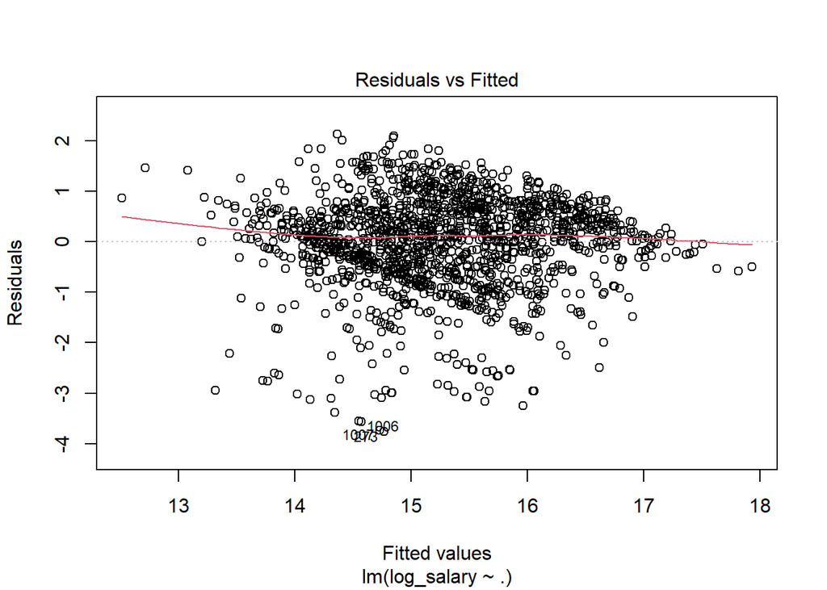

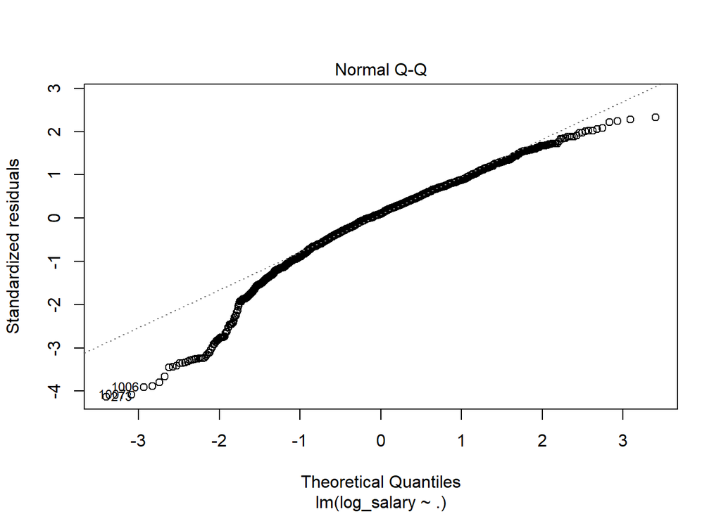

```r
plot(ols.log, which = c(1, 2))
```

```r
vif(ols.log)
```

```
##                     GVIF Df GVIF^(1/(2*Df))
## career_AST     10.510610  1        3.242007
## career_G       14.569538  1        3.817006
## career_PER     13.873845  1        3.724761
## career_PTS     15.266460  1        3.907232
## career_TRB     11.341982  1        3.367786
## career_WS       6.644145  1        2.577624
## career_eFG_P   10.958310  1        3.310334
## draft_pick      5.185740  1        2.277222
## draft_round     4.377913  1        2.092346
## draft_year      8.841679  1        2.973496
## height          5.680537  1        2.383388
## weight          4.212597  1        2.052461
## Pos            26.307269 11        1.160243
## Age            10.395348  1        3.224182
## G               1.909437  1        1.381824
## GS              3.453894  1        1.858465
## MP             14.804590  1        3.847673
## FG           4733.185068  1       68.798147
## FGA          8859.194312  1       94.123293
## FG_P           41.639558  1        6.452872
## THREEP        534.699518  1       23.123571
## THREEP_A     1863.249561  1       43.165375
## THREEP_P        2.785189  1        1.668888
## TWOP         1601.252622  1       40.015655
## TWOP_A       5031.772193  1       70.934986
## TWOP_P          6.309483  1        2.511868
## eFG_P          28.019402  1        5.293336
## FT            458.051952  1       21.402148
## FTA            88.240059  1        9.393618
## FT_P            2.539259  1        1.593505
## ORB           247.139089  1       15.720658
## DRB          1394.042503  1       37.336879
## TRB          2470.819216  1       49.707336
## AST            11.975450  1        3.460556
## STL             2.774407  1        1.665655
## BLK             2.547526  1        1.596097
## TOV             9.757346  1        3.123675
## PF              3.028850  1        1.740359
## PTS          7183.248713  1       84.754048
## year            1.805858  1        1.343822
## career_FG3_P    3.452901  1        1.858198
## career_FG_P    19.694741  1        4.437876
## career_FT_P     2.683681  1        1.638194
## shoots_right    1.091761  1        1.044874
```

```r
vifs <- data.frame(vif(ols.log))

vifs %>%
  filter(GVIF > 1000) ->
vif.1000

drop.vars <- c(rownames(vif.1000))

bdata.log.rm %>%
  select(-drop.vars) ->
bdata.log2
```

```
## Note: Using an external vector in selections is ambiguous.
## i Use `all_of(drop.vars)` instead of `drop.vars` to silence this message.
## i See <https://tidyselect.r-lib.org/reference/faq-external-vector.html>.
```

### VIF Fit 2

```r
ols.log2 <- lm(log_salary ~ ., data = bdata.log2)

summary(ols.log2)
```

```
##
## Call:
## lm(formula = log_salary ~ ., data = bdata.log2)
##
## Residuals:
##     Min      1Q  Median      3Q     Max
## -3.8044 -0.4568  0.1099  0.6103  2.0923
##
## Coefficients:
##                Estimate Std. Error t value Pr(>|t|)
## (Intercept)  -2.986e+02  5.382e+01  -5.548 3.43e-08 ***
## career_AST   -6.193e-02  4.533e-02  -1.366 0.172115
## career_G      1.086e-03  3.033e-04   3.579 0.000356 ***
## career_PER    1.380e-02  2.192e-02   0.629 0.529178
## career_PTS   -1.243e-02  1.653e-02  -0.752 0.451963
## career_TRB    1.342e-03  2.988e-02   0.045 0.964170
## career_WS    -6.477e-04  1.988e-03  -0.326 0.744605
## career_eFG_P  8.790e-03  1.785e-02   0.493 0.622439
## draft_pick   -4.564e-03  3.550e-03  -1.286 0.198821
## draft_round   5.752e-02  1.038e-01   0.554 0.579596
## draft_year   -3.493e-02  1.513e-02  -2.309 0.021109 *
## height        3.796e-02  1.737e-02   2.186 0.029000 *
## weight       -2.066e-04  2.088e-03  -0.099 0.921183
## PosC-PF       9.568e-02  4.754e-01   0.201 0.840506
## PosPF        -1.098e-02  1.040e-01  -0.106 0.915909
## PosPF-C      -1.436e-01  9.435e-01  -0.152 0.879053
## PosPF-SF     -2.162e-02  5.536e-01  -0.039 0.968851
## PosPG        -3.133e-02  2.018e-01  -0.155 0.876652
## PosPG-SG     -7.444e-01  9.677e-01  -0.769 0.441841
## PosSF        -4.379e-02  1.408e-01  -0.311 0.755808
## PosSF-PF      5.676e-01  9.592e-01   0.592 0.554091
## PosSF-SG      5.076e-01  5.613e-01   0.904 0.365939
## PosSG         1.923e-02  1.683e-01   0.114 0.909017
## PosSG-PF     -8.996e-02  9.526e-01  -0.094 0.924777
## Age          -3.722e-02  1.799e-02  -2.069 0.038729 *
## G             2.918e-03  1.456e-03   2.004 0.045225 *
## GS            5.189e-03  1.611e-03   3.222 0.001304 **
## MP            3.182e-02  9.612e-03   3.311 0.000953 ***
## FG_P         -9.424e-01  1.897e+00  -0.497 0.619455
## THREEP        6.902e-02  8.140e-02   0.848 0.396628
```

[output cut: 8 more lines]

```
## STL           2.875e-01  9.477e-02   3.034 0.002459 **
## BLK           9.487e-02  9.430e-02   1.006 0.314574
## TOV           2.761e-01  8.745e-02   3.157 0.001625 **
## PF           -2.451e-01  5.852e-02  -4.189 2.97e-05 ***
## year          1.881e-01  2.881e-02   6.530 9.05e-11 ***
## career_FG3_P  1.740e-02  5.279e-03   3.295 0.001008 **
## career_FG_P   1.093e-02  1.993e-02   0.548 0.583576
## career_FT_P   5.553e-03  4.180e-03   1.329 0.184203
## shoots_right  7.854e-02  9.392e-02   0.836 0.403117
## ---
## Signif. codes:  0 '***' 0.001 '**' 0.01 '*' 0.05 '.' 0.1 ' ' 1
##
## Residual standard error: 0.9329 on 1449 degrees of freedom
## Multiple R-squared:  0.438,  Adjusted R-squared:  0.4202
## F-statistic: 24.55 on 46 and 1449 DF,  p-value: < 2.2e-16
```

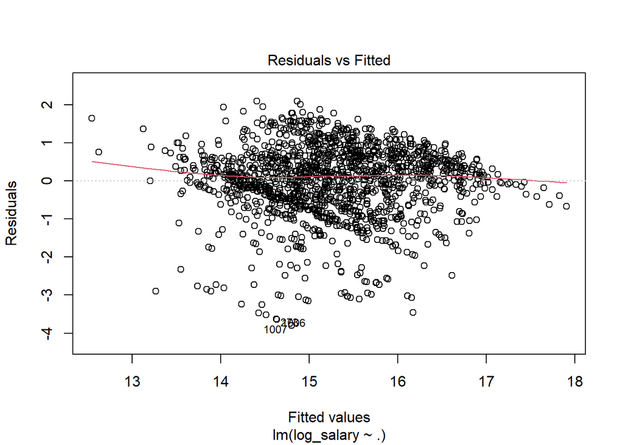

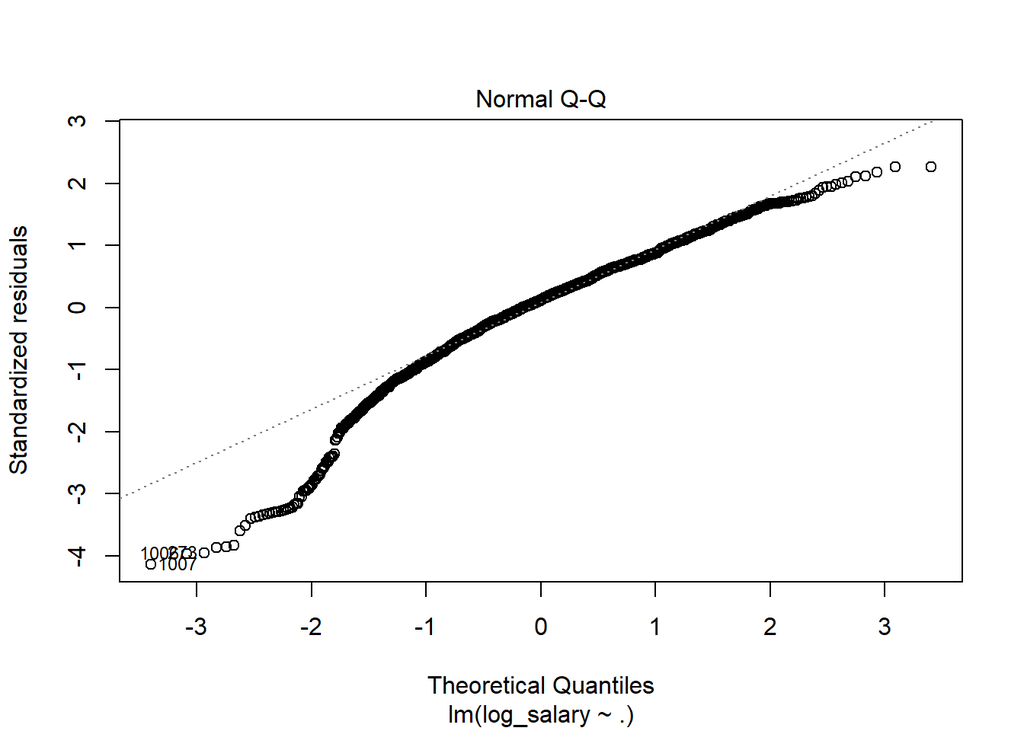

```r
plot(ols.log2, which = c(1, 2))
```

```r
vif(ols.log2)
```

```
##                   GVIF Df GVIF^(1/(2*Df))
## career_AST    9.803010  1        3.130976
## career_G     14.178864  1        3.765483
## career_PER   13.277477  1        3.643827
## career_PTS   11.706050  1        3.421411
## career_TRB    7.298674  1        2.701606
## career_WS     6.281686  1        2.506329
## career_eFG_P 10.703367  1        3.271600
## draft_pick    5.152386  1        2.269887
## draft_round   4.349012  1        2.085429
## draft_year    8.766464  1        2.960821
## height        5.634817  1        2.373777
## weight        4.190283  1        2.047018
## Pos          24.857344 11        1.157257
## Age          10.354663  1        3.217866
## G             1.894101  1        1.376263
## GS            3.386724  1        1.840306
## MP           10.903595  1        3.302059
## FG_P         34.043396  1        5.834672
## THREEP        7.608407  1        2.758334
## THREEP_P      2.665705  1        1.632699
## TWOP_P        4.173826  1        2.042994
## eFG_P        24.137387  1        4.912981
## FT           82.701784  1        9.094052
## FTA          84.003561  1        9.165346
## FT_P          2.505054  1        1.582736
## ORB           5.594889  1        2.365352
## AST          11.745119  1        3.427115
## STL           2.739982  1        1.655289
## BLK           2.488797  1        1.577592
## TOV           8.947857  1        2.991297
## PF            2.916320  1        1.707724
## year          1.760289  1        1.326759
## career_FG3_P  3.325888  1        1.823702
## career_FG_P  19.311947  1        4.394536
## career_FT_P   2.661358  1        1.631367
## shoots_right  1.084454  1        1.041371
```

```r
vifs2 <- data.frame(vif(ols.log2))

vifs2 %>%
  filter(GVIF > 50) ->
vif.50

drop.vars <- c(drop.vars, rownames(vif.50))

bdata.log.rm %>%
  select(-drop.vars) ->
bdata.log3
```

### VIF Fit 3

```r
ols.log3 <- lm(log_salary ~ ., data = bdata.log3)

summary(ols.log3)
```

```
##
## Call:
## lm(formula = log_salary ~ ., data = bdata.log3)
##
## Residuals:
##     Min      1Q  Median      3Q     Max
## -3.8016 -0.4560  0.1147  0.6169  2.0985
##
## Coefficients:
##                Estimate Std. Error t value Pr(>|t|)
## (Intercept)  -2.966e+02  5.379e+01  -5.514 4.15e-08 ***
## career_AST   -6.371e-02  4.399e-02  -1.448 0.147719
## career_G      1.058e-03  3.009e-04   3.515 0.000453 ***
## career_PER    1.743e-02  2.125e-02   0.820 0.412088
## career_PTS   -1.271e-02  1.630e-02  -0.780 0.435636
## career_TRB   -3.462e-03  2.945e-02  -0.118 0.906418
## career_WS    -5.445e-04  1.975e-03  -0.276 0.782780
## career_eFG_P  8.650e-03  1.783e-02   0.485 0.627589
## draft_pick   -4.389e-03  3.548e-03  -1.237 0.216297
## draft_round   5.053e-02  1.037e-01   0.487 0.626004
## draft_year   -3.556e-02  1.511e-02  -2.353 0.018761 *
## height        3.843e-02  1.733e-02   2.218 0.026742 *
## weight       -2.230e-04  2.088e-03  -0.107 0.914937
## PosC-PF       9.971e-02  4.753e-01   0.210 0.833854
## PosPF        -1.201e-02  1.040e-01  -0.115 0.908068
## PosPF-C      -1.387e-01  9.435e-01  -0.147 0.883141
## PosPF-SF     -1.281e-02  5.536e-01  -0.023 0.981538
## PosPG        -5.023e-02  2.014e-01  -0.249 0.803039
## PosPG-SG     -7.437e-01  9.676e-01  -0.769 0.442246
## PosSF        -5.262e-02  1.405e-01  -0.375 0.708031
## PosSF-PF      5.234e-01  9.583e-01   0.546 0.585009
## PosSF-SG      4.848e-01  5.607e-01   0.865 0.387381
## PosSG         4.217e-03  1.679e-01   0.025 0.979963
## PosSG-PF     -9.919e-02  9.524e-01  -0.104 0.917068
## Age          -3.650e-02  1.798e-02  -2.030 0.042562 *
## G             2.914e-03  1.455e-03   2.003 0.045347 *
## GS            5.387e-03  1.603e-03   3.360 0.000799 ***
## MP            3.066e-02  9.508e-03   3.225 0.001288 **
## FG_P         -5.584e-01  1.879e+00  -0.297 0.766310
## THREEP        9.428e-02  7.949e-02   1.186 0.235811
## THREEP_P     -6.132e-01  3.269e-01  -1.876 0.060885 .
## TWOP_P       -2.140e-01  5.759e-01  -0.372 0.710232
## eFG_P        -5.252e-01  1.685e+00  -0.312 0.755397
## FT_P         -3.730e-01  2.712e-01  -1.375 0.169344
## ORB           6.500e-02  7.525e-02   0.864 0.387827
## AST           3.116e-02  4.497e-02   0.693 0.488460
## STL           2.877e-01  9.474e-02   3.036 0.002438 **
## BLK           8.538e-02  9.401e-02   0.908 0.363891
## TOV           2.713e-01  8.051e-02   3.370 0.000772 ***
## PF           -2.470e-01  5.836e-02  -4.233 2.45e-05 ***
## year          1.877e-01  2.881e-02   6.515 9.99e-11 ***
## career_FG3_P  1.807e-02  5.258e-03   3.437 0.000604 ***
## career_FG_P   8.889e-03  1.986e-02   0.448 0.654464
## career_FT_P   6.020e-03  4.163e-03   1.446 0.148389
## shoots_right  8.360e-02  9.379e-02   0.891 0.372939
## ---
## Signif. codes:  0 '***' 0.001 '**' 0.01 '*' 0.05 '.' 0.1 ' ' 1
##
## Residual standard error: 0.933 on 1451 degrees of freedom
## Multiple R-squared:  0.4372, Adjusted R-squared:  0.4201
## F-statistic: 25.62 on 44 and 1451 DF,  p-value: < 2.2e-16
```

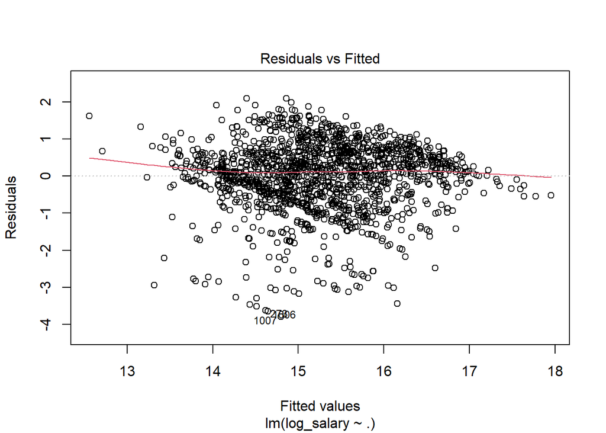

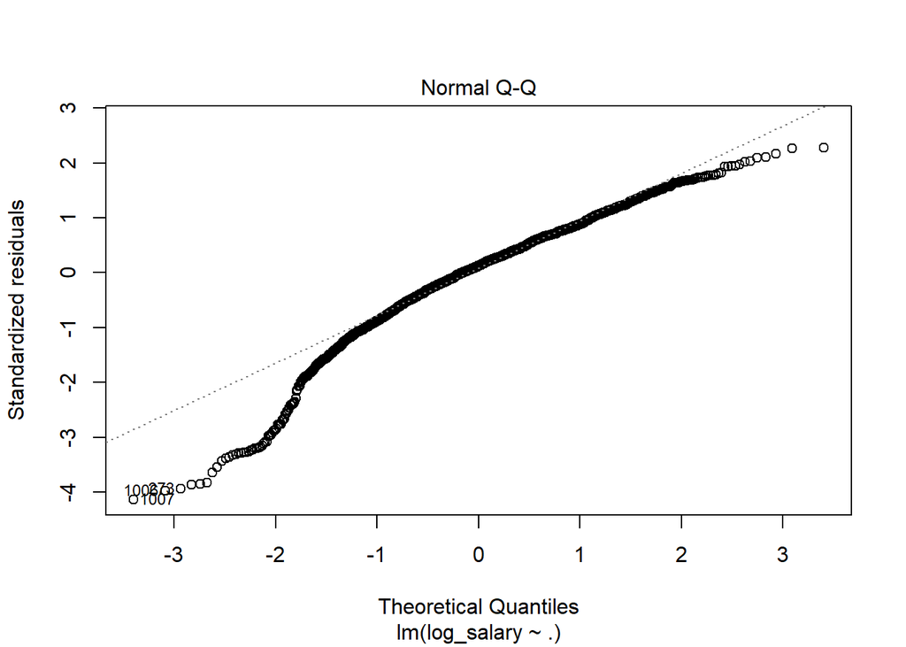

```r
plot(ols.log3, which = c(1, 2))
```

```r
vif(ols.log3)
```

```
##                   GVIF Df GVIF^(1/(2*Df))
## career_AST    9.229331  1        3.037981
## career_G     13.960353  1        3.736356
## career_PER   12.476906  1        3.532266
## career_PTS   11.382015  1        3.373724
## career_TRB    7.089287  1        2.662572
## career_WS     6.196646  1        2.489306
## career_eFG_P 10.677575  1        3.267656
## draft_pick    5.146503  1        2.268591
## draft_round   4.337020  1        2.082551
## draft_year    8.748132  1        2.957724
## height        5.609227  1        2.368381
## weight        4.187806  1        2.046413
## Pos          24.444378 11        1.156376
## Age          10.341004  1        3.215743
## G             1.891787  1        1.375422
## GS            3.355003  1        1.831667
## MP           10.666554  1        3.265969
## FG_P         33.372109  1        5.776860
## THREEP        7.254844  1        2.693482
## THREEP_P      2.660077  1        1.630974
## TWOP_P        4.173313  1        2.042869
## eFG_P        23.597206  1        4.857696
## FT_P          1.928571  1        1.388730
## ORB           5.531125  1        2.351834
## AST          11.647324  1        3.412818
## STL           2.737946  1        1.654674
## BLK           2.473016  1        1.572583
## TOV           7.584435  1        2.753985
## PF            2.899754  1        1.702866
## year          1.760065  1        1.326675
## career_FG3_P  3.298961  1        1.816304
## career_FG_P  19.173978  1        4.378810
## career_FT_P   2.640020  1        1.624814
## shoots_right  1.081532  1        1.039967
```

```r
vifs3 <- data.frame(vif(ols.log3))

vifs3 %>%
  filter(GVIF > 20) ->
vif.20

drop.vars <- c(drop.vars, rownames(vif.20))

bdata.log.rm %>%
  select(-drop.vars) ->
bdata.log4
```

### VIF Fit 4

```r
ols.log4 <- lm(log_salary ~ ., data = bdata.log4)

summary(ols.log4)
```

```
##
## Call:
## lm(formula = log_salary ~ ., data = bdata.log4)
##
## Residuals:
##     Min      1Q  Median      3Q     Max
## -3.7944 -0.4667  0.1071  0.6112  2.1903
##
## Coefficients:
##                Estimate Std. Error t value Pr(>|t|)
## (Intercept)  -3.055e+02  5.299e+01  -5.765 9.97e-09 ***
## career_AST   -6.807e-02  4.108e-02  -1.657 0.097682 .
## career_G      1.070e-03  2.977e-04   3.594 0.000336 ***
## career_PER    1.803e-02  2.040e-02   0.884 0.376847
## career_PTS   -1.058e-02  1.521e-02  -0.696 0.486758
## career_TRB   -3.572e-03  2.868e-02  -0.125 0.900895
## career_WS    -5.898e-04  1.958e-03  -0.301 0.763248
## career_eFG_P  7.117e-03  1.470e-02   0.484 0.628430
## draft_pick   -4.023e-03  3.509e-03  -1.146 0.251841
## draft_round   4.550e-02  1.027e-01   0.443 0.657859
## draft_year   -3.522e-02  1.485e-02  -2.371 0.017866 *
## height        4.058e-02  1.454e-02   2.792 0.005307 **
## weight       -1.937e-04  1.962e-03  -0.099 0.921356
## Age          -3.739e-02  1.786e-02  -2.093 0.036510 *
## G             2.841e-03  1.437e-03   1.977 0.048236 *
## GS            5.342e-03  1.589e-03   3.362 0.000794 ***
## MP            3.049e-02  9.150e-03   3.332 0.000883 ***
## THREEP        9.298e-02  6.419e-02   1.449 0.147677
## THREEP_P     -8.334e-01  2.605e-01  -3.199 0.001408 **
## TWOP_P       -7.833e-01  3.446e-01  -2.273 0.023157 *
## FT_P         -3.670e-01  2.683e-01  -1.368 0.171503
## ORB           5.354e-02  7.259e-02   0.738 0.460905
## AST           2.911e-02  4.424e-02   0.658 0.510587
## STL           2.919e-01  9.067e-02   3.220 0.001310 **
## BLK           8.711e-02  9.156e-02   0.951 0.341563
## TOV           2.728e-01  7.883e-02   3.460 0.000555 ***
## PF           -2.479e-01  5.721e-02  -4.333 1.57e-05 ***
## year          1.917e-01  2.829e-02   6.774 1.81e-11 ***
## career_FG3_P  1.980e-02  4.967e-03   3.986 7.04e-05 ***
## career_FG_P   6.572e-03  1.667e-02   0.394 0.693481
## career_FT_P   5.645e-03  4.091e-03   1.380 0.167793
## shoots_right  9.226e-02  9.260e-02   0.996 0.319261
## ---
## Signif. codes:  0 '***' 0.001 '**' 0.01 '*' 0.05 '.' 0.1 ' ' 1
##
## Residual standard error: 0.9302 on 1464 degrees of freedom
## Multiple R-squared:  0.4355, Adjusted R-squared:  0.4236
## F-statistic: 36.44 on 31 and 1464 DF,  p-value: < 2.2e-16
```

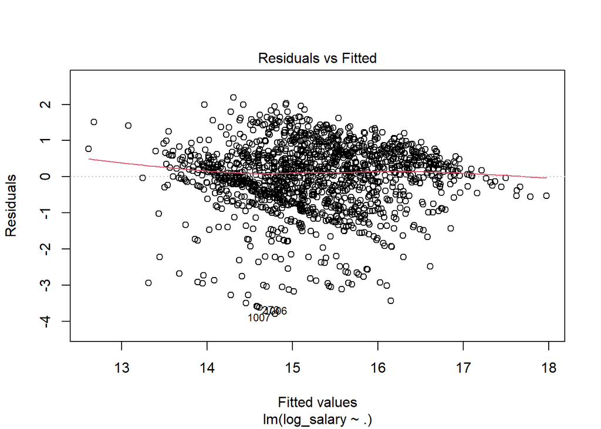

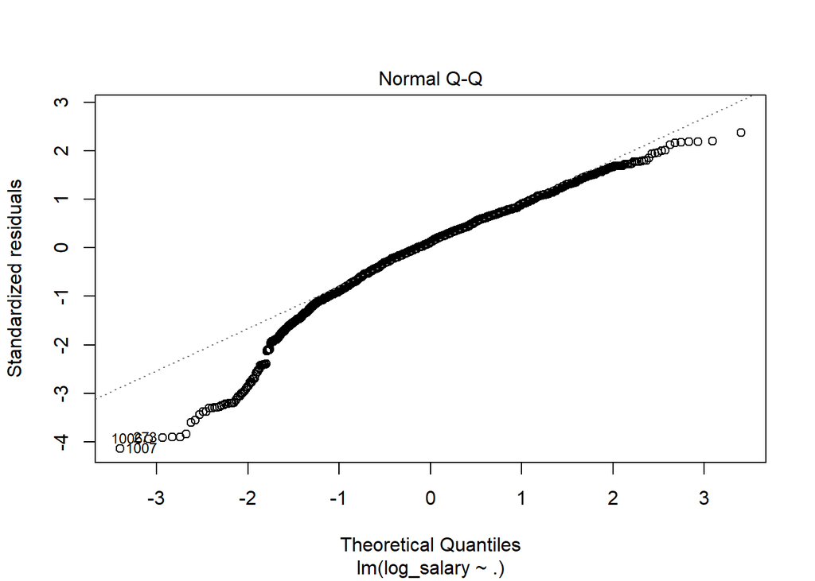

```r
plot(ols.log4, which = c(1, 2))
```

```r
vif(ols.log4)
```

```
##   career_AST     career_G   career_PER   career_PTS   career_TRB    career_WS
##     8.096840    13.738779    11.565474     9.975993     6.764560     6.126678
## career_eFG_P   draft_pick  draft_round   draft_year       height       weight
##     7.307411     5.063636     4.283062     8.498477     3.969747     3.719946
##          Age            G           GS           MP       THREEP     THREEP_P
##    10.268523     1.856840     3.315380     9.937331     4.758447     1.699601
##       TWOP_P         FT_P          ORB          AST          STL          BLK
##     1.502783     1.897745     5.177728    11.341495     2.522777     2.360051
##          TOV           PF         year career_FG3_P  career_FG_P  career_FT_P
##     7.314608     2.803793     1.707789     2.961026    13.595981     2.564364
## shoots_right
##     1.060467
```

```r
vifs4 <- data.frame(vif(ols.log4))

vifs4 %>%
  filter(`vif.ols.log4.` > 12) ->
vif.12

drop.vars <- c(drop.vars, rownames(vif.12))

bdata.log.rm %>%
  select(-drop.vars) ->
bdata.log5
```

### VIF Final Fit

Here is the final final of the features selected using VIF. We will refer to this as the `VIF` feature set.

```r
ols.log5 <- lm(log_salary ~ ., data = bdata.log5)

summary(ols.log5)
```

```
##
## Call:
## lm(formula = log_salary ~ ., data = bdata.log5)
##
## Residuals:
##     Min      1Q  Median      3Q     Max
## -3.7554 -0.4594  0.1029  0.6297  2.2262
##
## Coefficients:
##                Estimate Std. Error t value Pr(>|t|)
## (Intercept)  -2.329e+02  4.905e+01  -4.748 2.25e-06 ***
## career_AST   -7.273e-02  4.121e-02  -1.765 0.077798 .
## career_PER    1.331e-02  1.756e-02   0.758 0.448519
## career_PTS   -7.438e-03  1.520e-02  -0.489 0.624761
## career_TRB   -7.351e-04  2.875e-02  -0.026 0.979608
## career_WS     2.794e-03  1.652e-03   1.691 0.090969 .
## career_eFG_P  1.294e-02  8.284e-03   1.562 0.118474
## draft_pick   -5.049e-03  3.509e-03  -1.439 0.150371
## draft_round  -1.177e-02  1.019e-01  -0.116 0.907996
## draft_year   -5.431e-02  1.392e-02  -3.902 9.99e-05 ***
## height        4.228e-02  1.452e-02   2.912 0.003647 **
## weight       -2.458e-04  1.967e-03  -0.125 0.900574
## Age          -4.716e-03  1.542e-02  -0.306 0.759803
## G             4.082e-03  1.401e-03   2.913 0.003636 **
## GS            4.664e-03  1.580e-03   2.953 0.003200 **
## MP            3.591e-02  8.947e-03   4.014 6.27e-05 ***
## THREEP        6.269e-02  5.551e-02   1.129 0.258902
## THREEP_P     -8.553e-01  2.606e-01  -3.282 0.001057 **
## TWOP_P       -7.151e-01  3.451e-01  -2.072 0.038427 *
## FT_P         -3.593e-01  2.690e-01  -1.336 0.181872
## ORB           2.736e-02  7.235e-02   0.378 0.705402
## AST           1.810e-02  4.423e-02   0.409 0.682504
## STL           2.878e-01  9.055e-02   3.178 0.001511 **
## BLK           6.923e-02  9.168e-02   0.755 0.450289
## TOV           2.905e-01  7.891e-02   3.681 0.000241 ***
## PF           -2.476e-01  5.716e-02  -4.331 1.59e-05 ***
## year          1.745e-01  2.778e-02   6.280 4.44e-10 ***
## career_FG3_P  1.807e-02  4.607e-03   3.922 9.17e-05 ***
## career_FT_P   5.738e-03  4.053e-03   1.416 0.157040
## shoots_right  8.199e-02  9.286e-02   0.883 0.377427
## ---
## Signif. codes:  0 '***' 0.001 '**' 0.01 '*' 0.05 '.' 0.1 ' ' 1
##
## Residual standard error: 0.9338 on 1466 degrees of freedom
## Multiple R-squared:  0.4304, Adjusted R-squared:  0.4191
## F-statistic:  38.2 on 29 and 1466 DF,  p-value: < 2.2e-16
```

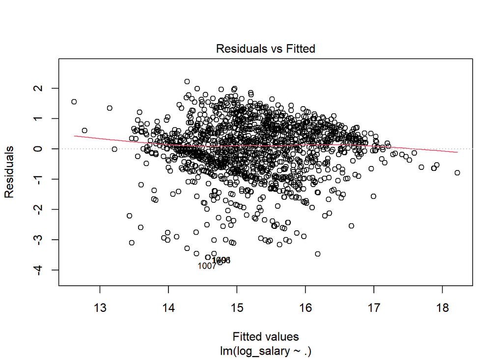

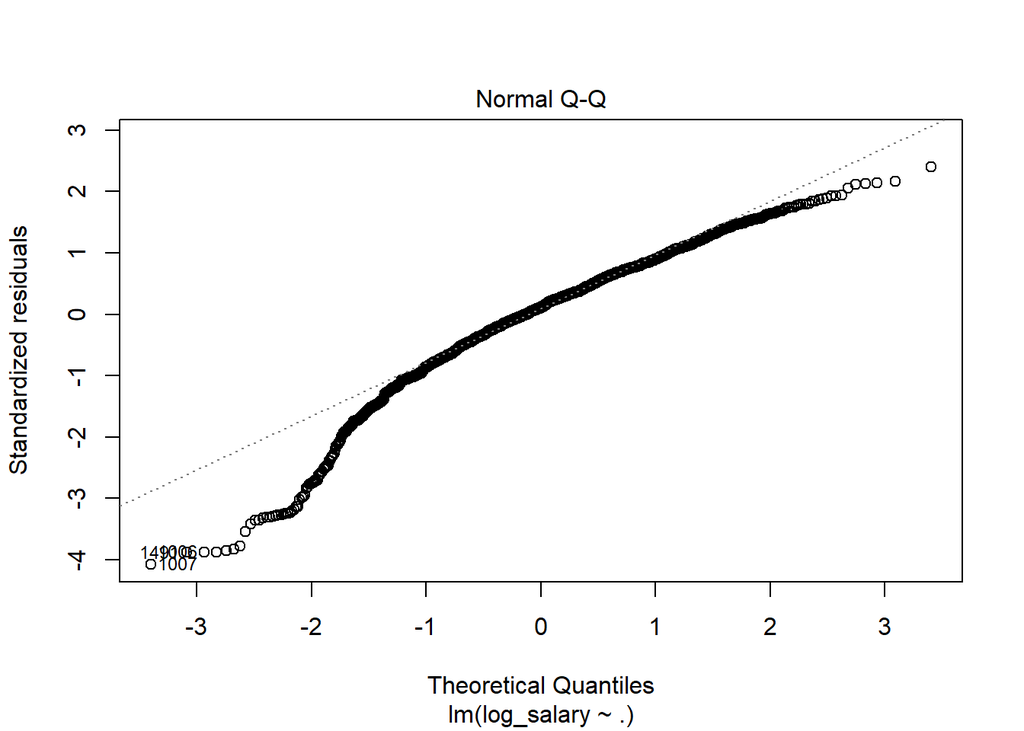

```r
plot(ols.log5, which = c(1, 2))
```

```r
vif(ols.log5)
```

```
##   career_AST   career_PER   career_PTS   career_TRB    career_WS career_eFG_P
##     8.088540     8.508500     9.889835     6.748269     4.330506     2.301490
##   draft_pick  draft_round   draft_year       height       weight          Age
##     5.024282     4.180753     7.406697     3.930851     3.712847     7.593035
##            G           GS           MP       THREEP     THREEP_P       TWOP_P
##     1.752457     3.251092     9.429299     3.531057     1.687969     1.495904
##         FT_P          ORB          AST          STL          BLK          TOV
##     1.894127     5.104051    11.250377     2.496857     2.347942     7.272996
##           PF         year career_FG3_P  career_FT_P shoots_right
##     2.777369     1.633453     2.527869     2.498199     1.058319
```

## Removing High Leverage Outliers

We can further remove extreme datapoints by removing high leverage values.

```r
high.lev <- c()
for (i in seq(length(hatvalues(ols.log5)))) {
  if (hatvalues(ols.log5)[i] > 2*mean(hatvalues(ols.log5))){
    high.lev <- c(high.lev, i)
  }
}

bdata.log.rm <- bdata.log.rm[-high.lev,]

bdata.log.rm %>%
  select(-drop.vars) ->
bdata.vif
```

### VIF Final Fit (High Leverage Removed)

```r
ols.vif <- lm(log_salary ~ ., data = bdata.vif)

summary(ols.vif)
```

```
##
## Call:
## lm(formula = log_salary ~ ., data = bdata.vif)
##
## Residuals:
##     Min      1Q  Median      3Q     Max
## -3.9286 -0.4543  0.1067  0.6066  2.3801
##
## Coefficients:
##                Estimate Std. Error t value Pr(>|t|)
## (Intercept)  -2.320e+02  5.179e+01  -4.479 8.12e-06 ***
## career_AST   -8.548e-02  4.449e-02  -1.921 0.054927 .
## career_PER    1.610e-03  1.936e-02   0.083 0.933706
## career_PTS   -1.138e-02  1.634e-02  -0.696 0.486461
## career_TRB    3.106e-02  3.167e-02   0.981 0.326934
## career_WS     4.521e-03  2.223e-03   2.033 0.042207 *
## career_eFG_P  2.178e-02  1.014e-02   2.147 0.031930 *
## draft_pick   -4.736e-03  3.636e-03  -1.302 0.192994
## draft_round  -1.146e-02  1.099e-01  -0.104 0.916966
## draft_year   -8.770e-02  2.305e-02  -3.804 0.000148 ***
## height        4.657e-02  1.525e-02   3.054 0.002298 **
## weight       -1.135e-03  2.035e-03  -0.558 0.577200
## Age          -3.648e-02  2.117e-02  -1.723 0.085165 .
## G             4.332e-03  1.456e-03   2.976 0.002972 **
## GS            3.817e-03  1.612e-03   2.369 0.017990 *
## MP            3.732e-02  9.387e-03   3.976 7.38e-05 ***
## THREEP        7.134e-02  5.960e-02   1.197 0.231517
## THREEP_P     -1.623e+00  3.578e-01  -4.537 6.21e-06 ***
## TWOP_P       -8.281e-01  4.355e-01  -1.901 0.057449 .
## FT_P         -8.141e-01  3.273e-01  -2.487 0.012986 *
## ORB          -9.596e-02  8.244e-02  -1.164 0.244641
## AST           3.997e-02  4.762e-02   0.839 0.401371
## STL           2.867e-01  9.581e-02   2.992 0.002820 **
## BLK           8.436e-02  1.023e-01   0.824 0.409804
## TOV           2.894e-01  8.614e-02   3.359 0.000802 ***
## PF           -2.226e-01  5.965e-02  -3.732 0.000198 ***
## year          2.074e-01  3.218e-02   6.445 1.59e-10 ***
## career_FG3_P  2.243e-02  5.737e-03   3.909 9.73e-05 ***
## career_FT_P   1.328e-02  5.175e-03   2.566 0.010404 *
## shoots_right  5.007e-02  9.696e-02   0.516 0.605646
## ---
## Signif. codes:  0 '***' 0.001 '**' 0.01 '*' 0.05 '.' 0.1 ' ' 1
##
## Residual standard error: 0.9197 on 1374 degrees of freedom
## Multiple R-squared:  0.4271, Adjusted R-squared:  0.4151
## F-statistic: 35.33 on 29 and 1374 DF,  p-value: < 2.2e-16
```

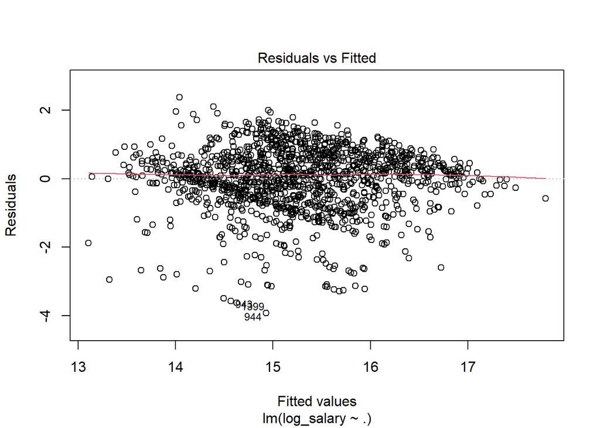

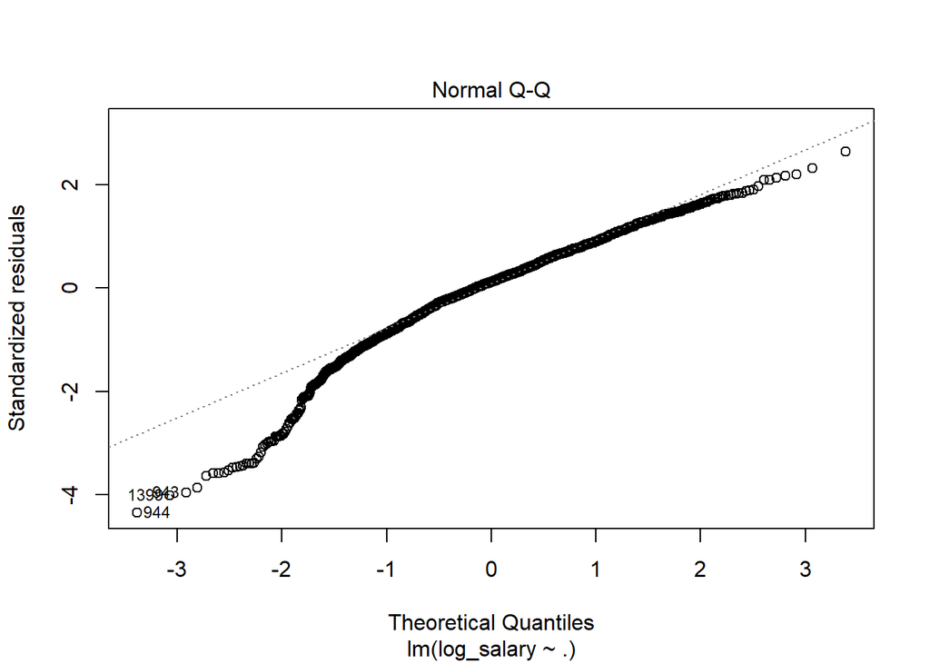

```r
plot(ols.vif, which = c(1, 2))
```

```r
vif(ols.vif)
```

```
##   career_AST   career_PER   career_PTS   career_TRB    career_WS career_eFG_P
##     8.149515     8.554315    10.049620     6.695920     5.574405     2.452272
##   draft_pick  draft_round   draft_year       height       weight          Age
##     4.861985     3.767066    15.804386     4.062365     3.660954    13.435904
##            G           GS           MP       THREEP     THREEP_P       TWOP_P
##     1.710995     3.209854     9.480160     3.671023     2.314496     1.628436
##         FT_P          ORB          AST          STL          BLK          TOV
##     2.158277     5.239902    11.375639     2.464197     2.364785     7.445836
##           PF         year career_FG3_P  career_FT_P shoots_right
##     2.769412     2.095454     2.963148     2.901556     1.060887
```

## Feature Selection Use Stepwise Function

Another way we can select features is by using `step()`.

```r
fit.large <- lm(log_salary ~ ., data = bdata.log.rm)

fit.small <- lm(log_salary ~ 1, data = bdata.log.rm)

fit.step <- step(fit.large, fit.small)
```

```
## Start:  AIC=-186.43
## log_salary ~ career_AST + career_G + career_PER + career_PTS +
##     career_TRB + career_WS + career_eFG_P + draft_pick + draft_round +
##     draft_year + height + weight + Pos + Age + G + GS + MP +
##     FG + FGA + FG_P + THREEP + THREEP_A + THREEP_P + TWOP + TWOP_A +
##     TWOP_P + eFG_P + FT + FTA + FT_P + ORB + DRB + TRB + AST +
##     STL + BLK + TOV + PF + PTS + year + career_FG3_P + career_FG_P +
##     career_FT_P + shoots_right
##
##                Df Sum of Sq    RSS     AIC
## - Pos          10    2.5845 1141.0 -203.25
## - draft_round   1    0.0001 1138.4 -188.43
## - career_eFG_P  1    0.0135 1138.4 -188.41
## - TWOP_A        1    0.0495 1138.4 -188.37
## - THREEP_A      1    0.0602 1138.5 -188.36
## - weight        1    0.1397 1138.5 -188.26
## - shoots_right  1    0.1552 1138.5 -188.24
## - TWOP          1    0.1559 1138.5 -188.24
## - TWOP_P        1    0.1672 1138.6 -188.22
## - FGA           1    0.2110 1138.6 -188.17
## - AST           1    0.6422 1139.0 -187.64
## - FTA           1    0.7488 1139.1 -187.51
## - TRB           1    0.8080 1139.2 -187.43
## - draft_pick    1    0.8586 1139.2 -187.37
## - career_WS     1    0.8617 1139.2 -187.37
## - DRB           1    0.9280 1139.3 -187.29
## - FG_P          1    0.9574 1139.3 -187.25
## - ORB           1    1.0107 1139.4 -187.18
## - draft_year    1    1.0410 1139.4 -187.15
## - BLK           1    1.0644 1139.5 -187.12
## - eFG_P         1    1.1432 1139.5 -187.02
## - career_PER    1    1.1735 1139.6 -186.98
## - career_PTS    1    1.2851 1139.7 -186.85
## - THREEP        1    1.5003 1139.9 -186.58
## - FG            1    1.5342 1139.9 -186.54
## <none>                      1138.4 -186.43
## - career_AST    1    1.6984 1140.1 -186.34
## - career_FG_P   1    2.4260 1140.8 -185.44
## - career_TRB    1    2.5363 1140.9 -185.31
## - Age           1    2.9439 1141.3 -184.80
```

[output cut: 908 more lines]

```
## - FT            1     4.737 1156.4 -226.39
## - THREEP        1     5.221 1156.9 -225.81
## - career_FT_P   1     5.417 1157.1 -225.57
## - MP            1     5.724 1157.4 -225.19
## - FGA           1     6.364 1158.0 -224.42
## - STL           1     6.691 1158.3 -224.02
## - TOV           1     7.610 1159.3 -222.91
## - career_FG_P   1     8.412 1160.1 -221.94
## - GS            1     9.907 1161.6 -220.13
## - PF            1    11.363 1163.0 -218.37
## - THREEP_P      1    12.869 1164.5 -216.56
## - height        1    16.227 1167.9 -212.51
## - career_FG3_P  1    21.152 1172.8 -206.60
## - career_G      1    28.919 1180.6 -197.34
## - year          1    38.411 1190.1 -186.09
```

We will refer to this feature set as the `Step` feature set from now on.

## Handling the `VIF` and `Step` Feature Sets

```r
vars.vif <- names(vif(ols.log5))

vars.step <- names(fit.step$coefficients)[-1]
bdata.log.rm %>%
  select(c(vars.step, log_salary)) ->
bdata.step
```

```
## Note: Using an external vector in selections is ambiguous.
## i Use `all_of(vars.step)` instead of `vars.step` to silence this message.
## i See <https://tidyselect.r-lib.org/reference/faq-external-vector.html>.
```

## Validating Between the Feature Sets

Let’s do an anova test on the OLS model fitting all features and the 2 feature set models

```r
ols.log <- lm(log_salary ~ ., data = bdata.log.rm)

anova(ols.log, ols.vif)
```

```
## Analysis of Variance Table
##
## Model 1: log_salary ~ career_AST + career_G + career_PER + career_PTS +
##     career_TRB + career_WS + career_eFG_P + draft_pick + draft_round +
##     draft_year + height + weight + Pos + Age + G + GS + MP +
##     FG + FGA + FG_P + THREEP + THREEP_A + THREEP_P + TWOP + TWOP_A +
##     TWOP_P + eFG_P + FT + FTA + FT_P + ORB + DRB + TRB + AST +
##     STL + BLK + TOV + PF + PTS + year + career_FG3_P + career_FG_P +
##     career_FT_P + shoots_right
## Model 2: log_salary ~ career_AST + career_PER + career_PTS + career_TRB +
##     career_WS + career_eFG_P + draft_pick + draft_round + draft_year +
##     height + weight + Age + G + GS + MP + THREEP + THREEP_P +
##     TWOP_P + FT_P + ORB + AST + STL + BLK + TOV + PF + year +
##     career_FG3_P + career_FT_P + shoots_right
##   Res.Df    RSS  Df Sum of Sq      F Pr(>F)
## 1   1350 1138.4
## 2   1374 1162.2 -24   -23.798 1.1759 0.2535
```

```r
anova(ols.log, fit.step)
```

```
## Analysis of Variance Table
##
## Model 1: log_salary ~ career_AST + career_G + career_PER + career_PTS +
##     career_TRB + career_WS + career_eFG_P + draft_pick + draft_round +
##     draft_year + height + weight + Pos + Age + G + GS + MP +
##     FG + FGA + FG_P + THREEP + THREEP_A + THREEP_P + TWOP + TWOP_A +
##     TWOP_P + eFG_P + FT + FTA + FT_P + ORB + DRB + TRB + AST +
##     STL + BLK + TOV + PF + PTS + year + career_FG3_P + career_FG_P +
##     career_FT_P + shoots_right
## Model 2: log_salary ~ career_G + career_PTS + draft_pick + height + Age +
##     G + GS + MP + FG + FGA + THREEP + THREEP_P + FT + FT_P +
##     STL + BLK + TOV + PF + PTS + year + career_FG3_P + career_FG_P +
##     career_FT_P
##   Res.Df    RSS  Df Sum of Sq      F Pr(>F)
## 1   1350 1138.4
## 2   1380 1151.7 -30   -13.271 0.5246 0.9843
```

Both models are not significantly worse than the model fit on all predictors

## Creating the `Shared` Feature Set

Let’s do another anova on the feature set models and a small model fit only on the predictors they share.

```r
vars.share <- c()
for (i in vars.step) {
  if (i %in% vars.vif) {
    vars.share <- c(vars.share, i)
  } else {
    print(i)
  }
}
```

```
## [1] "career_G"
## [1] "FG"
## [1] "FGA"
## [1] "FT"
## [1] "PTS"
## [1] "career_FG_P"
```

```r
vars.share
```

```
##  [1] "career_PTS"   "draft_pick"   "height"       "Age"          "G"
##  [6] "GS"           "MP"           "THREEP"       "THREEP_P"     "FT_P"
## [11] "STL"          "BLK"          "TOV"          "PF"           "year"
## [16] "career_FG3_P" "career_FT_P"
```

```r
bdata.log.rm %>%
  select(c(vars.share, log_salary)) ->
bdata.share
```

```
## Note: Using an external vector in selections is ambiguous.
## i Use `all_of(vars.share)` instead of `vars.share` to silence this message.
## i See <https://tidyselect.r-lib.org/reference/faq-external-vector.html>.
```

```r
ols.share <- lm(log_salary ~ ., data = bdata.share)


anova(ols.share, fit.step)
```

```
## Analysis of Variance Table
##
## Model 1: log_salary ~ career_PTS + draft_pick + height + Age + G + GS +
##     MP + THREEP + THREEP_P + FT_P + STL + BLK + TOV + PF + year +
##     career_FG3_P + career_FT_P
## Model 2: log_salary ~ career_G + career_PTS + draft_pick + height + Age +
##     G + GS + MP + FG + FGA + THREEP + THREEP_P + FT + FT_P +
##     STL + BLK + TOV + PF + PTS + year + career_FG3_P + career_FG_P +
##     career_FT_P
##   Res.Df    RSS Df Sum of Sq      F    Pr(>F)
## 1   1386 1194.2
## 2   1380 1151.7  6    42.501 8.4879 4.526e-09 ***
## ---
## Signif. codes:  0 '***' 0.001 '**' 0.01 '*' 0.05 '.' 0.1 ' ' 1
```

```r
anova(ols.share, ols.vif)
```

```
## Analysis of Variance Table
##
## Model 1: log_salary ~ career_PTS + draft_pick + height + Age + G + GS +
##     MP + THREEP + THREEP_P + FT_P + STL + BLK + TOV + PF + year +
##     career_FG3_P + career_FT_P
## Model 2: log_salary ~ career_AST + career_PER + career_PTS + career_TRB +
##     career_WS + career_eFG_P + draft_pick + draft_round + draft_year +
##     height + weight + Age + G + GS + MP + THREEP + THREEP_P +
##     TWOP_P + FT_P + ORB + AST + STL + BLK + TOV + PF + year +
##     career_FG3_P + career_FT_P + shoots_right
##   Res.Df    RSS Df Sum of Sq      F    Pr(>F)
## 1   1386 1194.2
## 2   1374 1162.2 12    31.974 3.1501 0.0001905 ***
## ---
## Signif. codes:  0 '***' 0.001 '**' 0.01 '*' 0.05 '.' 0.1 ' ' 1
```

This new set of features will be called the `Shared` feature set.

Let’s do CV on the `Step`, `VIF`, and `Shared` feature subsets to see which is the best at prediction

# OLS Regression and Cross Validation on Each Feature Set

Here we will use Leave One Out Cross Validation

```r
library(boot)
ols.share <- glm(log_salary ~ ., data = bdata.share)

ols.vif <- glm(log_salary ~ ., data = bdata.vif)

ols.step <- glm(log_salary ~ ., data = bdata.step)

cv.share <- cv.glm(bdata.share, ols.share)

cv.vif <- cv.glm(bdata.vif, ols.vif)

cv.step <- cv.glm(bdata.step, ols.step)

c("Shared" = cv.share$delta[1], "VIF" = cv.vif$delta[1], "Step" = cv.step$delta[1])
```

```
##    Shared       VIF      Step
## 0.8744876 0.8675607 0.8507914
```

The OLS using the `Step` feature set has the best cross validation results. Well will keep this the mind as the best model moving forward.

# Weighted Least Squares Regression

Let’s now fit a model using WLS Regression on each of the feature sets, and see if any perform better than OLS Regression.

```r
# Shares Features
glm.share <- glm(log_salary ~ ., data= bdata.share)

glm.abs.res <- glm(abs(residuals(glm.share)) ~ fitted(glm.share))

wts.share <- 1/fitted(glm.abs.res)^2

bdata.share.wls <- bdata.share

wls.share <- glm(log_salary ~ ., data = bdata.share.wls, weights = wts.share)

bdata.share.wls$wts.share <- wts.share

cv.wls.share <- cv.glm(bdata.share.wls, wls.share)
```

```r
# VIF Features
glm.vif <- glm(log_salary ~ ., data = bdata.vif)

glm.abs.res <- glm(abs(residuals(glm.vif)) ~ fitted(glm.vif))

wts.vif <- 1/fitted(glm.abs.res)^2

bdata.vif.wls <- bdata.vif

wls.vif <- glm(log_salary ~ ., data = bdata.vif, weights = wts.vif)

bdata.vif.wls$wts.vif <- wts.vif

cv.wls.vif <- cv.glm(bdata.vif.wls, wls.vif)
```

```r
# Step Features

glm.step <- glm(log_salary ~ ., data = bdata.step)

glm.abs.res <- glm(abs(residuals(glm.step))~fitted(glm.step))

wts.step <- 1/fitted(glm.abs.res)^2

bdata.step.wls <- bdata.step

wls.step <- glm(log_salary ~ ., data = bdata.step, weights=wts.step)

bdata.step.wls$wts.step <- wts.step

cv.wls.step <- cv.glm(bdata.step.wls, wls.step)
```

## CV Results between Models and Feature Sets using Leave One Out

```r
cbind("WLS Share" = cv.wls.share$delta, "OLS Share" = cv.share$delta,
      "WLS VIF" = cv.wls.vif$delta, "OLS VIF" = cv.vif$delta,
      "WLS Step" = cv.wls.step$delta, "OLS Step" = cv.step$delta)
```

```
##      WLS Share OLS Share   WLS VIF   OLS VIF  WLS Step  OLS Step
## [1,] 0.8748360 0.8744876 0.8686742 0.8675607 0.8516867 0.8507914
## [2,] 0.8755225 0.8744790 0.8686925 0.8675463 0.8516831 0.8507804
```

Traditional OLS Regression using the `Step` Features is still producing the best CV results

# Regression Trees

Let’s now try another modeling method, Regression Trees, again using each feature set.

```r
library(tree)
```

[figure not shown]

```r
tree.share <- tree(log_salary ~ ., bdata.share, mindev = 0.0005)

tree.vif <- tree(log_salary ~ ., bdata.vif, mindev = 0.0005)

tree.step <- tree(log_salary ~ ., bdata.step, mindev = 0.0005)

plot(tree.share)
text(tree.share)
```

[figure not shown]

```r
plot(tree.vif)
text(tree.vif)
```

[figure not shown]

```r
plot(tree.step)
text(tree.step)
```

Our trees are overly complicated. Let’s prune the tree of each feature set to it’s minimum deviance.

## Pruning Share Tree

```r
set.seed(1)

cv.tree.share <- cv.tree(tree.share)

min.dev.share <- min(cv.tree.share$dev)

for (i in seq(length(cv.tree.share$dev))) {
  if (cv.tree.share$dev[i] == min.dev.share) {
    best.ind <- i
  }
}

best.size <- cv.tree.share$size[best.ind]

prune.share <- prune.tree(tree.share, best=best.size)

summary(prune.share)
```

```
##
## Regression tree:
## snip.tree(tree = tree.share, nodes = c(44L, 377L, 30L, 14L, 31L,
## 753L, 95L, 189L, 92L, 12L, 13L, 4L, 45L, 10L, 752L))
## Variables actually used in tree construction:
## [1] "MP"           "career_PTS"   "draft_pick"   "Age"          "career_FG3_P"
## [6] "GS"
## Number of terminal nodes:  17
## Residual mean deviance:  0.738 = 1024 / 1387
## Distribution of residuals:
##     Min.  1st Qu.   Median     Mean  3rd Qu.     Max.
## -4.22000 -0.39440  0.08196  0.00000  0.46570  3.01300
```

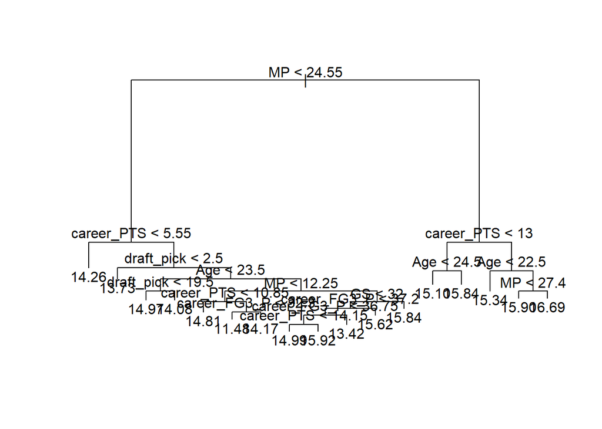

```r
plot(prune.share)
text(prune.share, pretty=0)
```

## Pruning VIF Tree

```r
set.seed(1)

cv.tree.vif <- cv.tree(tree.vif)

min.dev.vif <- min(cv.tree.vif$dev)

for (i in seq(length(cv.tree.vif$dev))) {
  if (cv.tree.vif$dev[i] == min.dev.vif) {
    best.ind <- i
  }
}

best.size <- cv.tree.vif$size[best.ind]

prune.vif <- prune.tree(tree.vif, best=best.size)

summary(prune.vif)
```

```
##
## Regression tree:
## snip.tree(tree = tree.vif, nodes = c(15L, 14L, 8L, 10L, 6L, 9L,
## 11L))
## Variables actually used in tree construction:
## [1] "MP"         "career_WS"  "draft_pick"
## Number of terminal nodes:  7
## Residual mean deviance:  0.8285 = 1157 / 1397
## Distribution of residuals:
##    Min. 1st Qu.  Median    Mean 3rd Qu.    Max.
## -4.2010 -0.4302  0.1084  0.0000  0.5473  3.2460
```

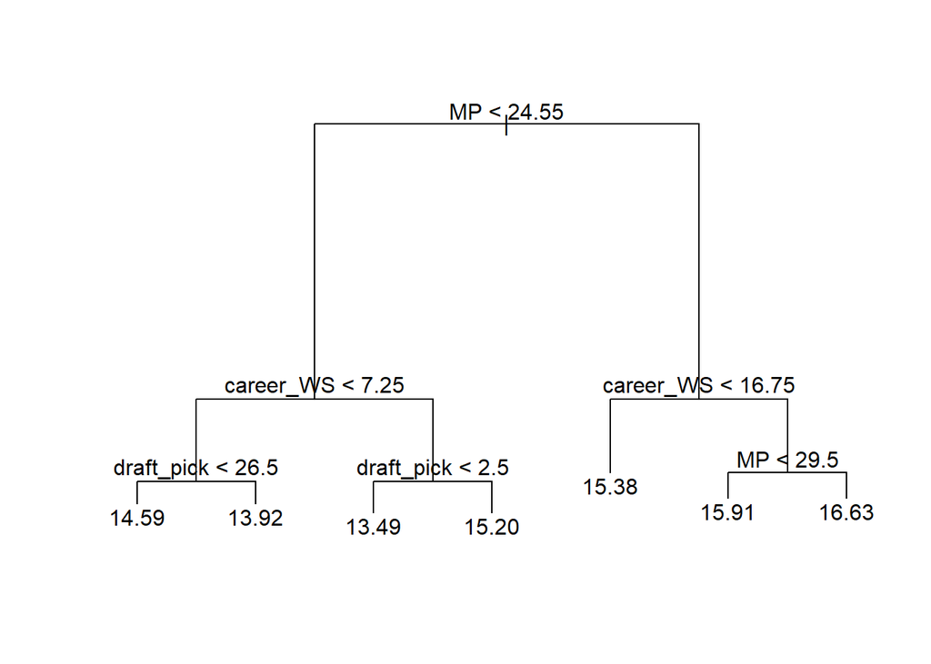

```r
plot(prune.vif)
text(prune.vif, pretty=0)
```

## Pruning Step Tree

```r
set.seed(1)

cv.tree.step <- cv.tree(tree.step)

min.dev.step <- min(cv.tree.step$dev)

for (i in seq(length(cv.tree.step$dev))) {
  if (cv.tree.step$dev[i] == min.dev.step) {
    best.ind <- i
  }
}

best.size <- cv.tree.step$size[best.ind]
best.size
```

```
## [1] 14
```

```r
prune.step <- prune.tree(tree.step, best=best.size)

summary(prune.step)
```

```
##
## Regression tree:
## snip.tree(tree = tree.step, nodes = c(19L, 44L, 15L, 18L, 12L,
## 187L, 8L, 47L, 14L, 45L, 13L, 186L, 92L, 10L))
## Variables actually used in tree construction:
## [1] "MP"          "career_G"    "draft_pick"  "G"           "career_PTS"
## [6] "career_FG_P" "career_FT_P" "PF"          "PTS"
## Number of terminal nodes:  14
## Residual mean deviance:  0.6964 = 968 / 1390
## Distribution of residuals:
##     Min.  1st Qu.   Median     Mean  3rd Qu.     Max.
## -4.68800 -0.37870  0.05666  0.00000  0.49250  3.25700
```

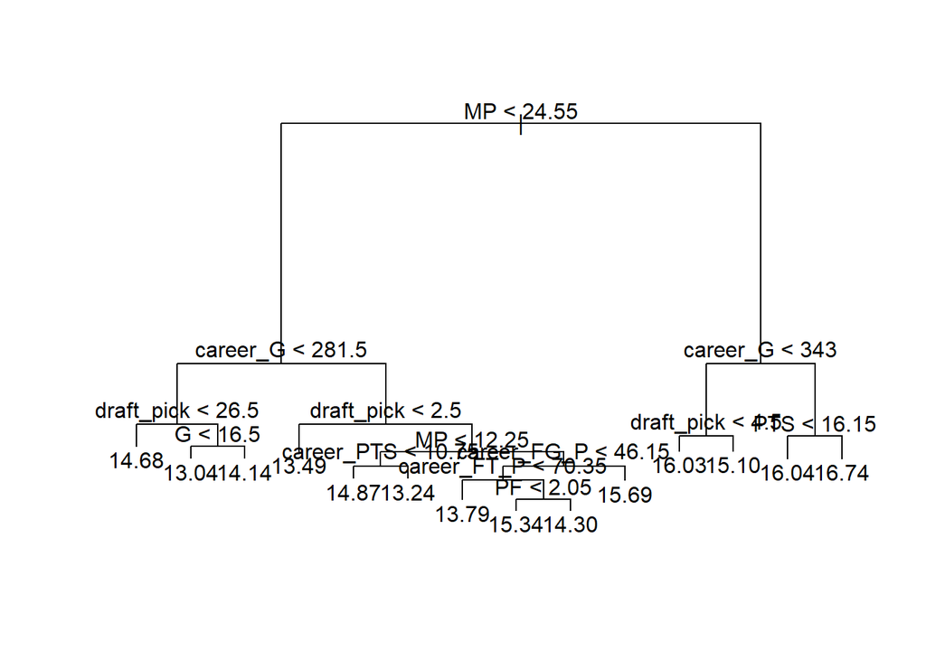

```r
plot(prune.step)
text(prune.step, pretty=0)
```

## Tree CV Results

```r
cbind("Tree Share" = min.dev.share, "Tree VIF" = min.dev.vif, "Tree Step" = min.dev.step)
```

```
##      Tree Share Tree VIF Tree Step
## [1,]   1298.234 1230.686   1118.14
```

The `Step` Feature set gives us the best performing Regression Tree

# Using CV to Determine the Best model

So far, the best modeling results have been `OLS` using the Step Feature Set, and Regression Trees using the `Step` Feature set.

## Compare Using Manual CV

Let’s compare Regresion Tree and OLS models using manual cross validation.

```r
cv <- function(t, r, s = 1) {

  tree.results <- c()
  ols.results <- c()

  for (i in 1:r) {
    set.seed(s - i + 1)
    train = sample(1:nrow(bdata.share), t*nrow(bdata.share))

    new.tree.step <- tree(log_salary ~ ., bdata.step[train,])
    pred.tree <- predict(new.tree.step, newdata = bdata.step[-train,])
    step.test <- bdata.step[-train, "log_salary"]
    tree.cv <- mean(c(((pred.tree - step.test)^2)[[1]]))

    new.ols.step <- lm(log_salary ~ ., bdata.step[train,])
    pred.ols <- predict(new.ols.step, newdata = bdata.step[-train,])
    step.test <- bdata.step[-train, "log_salary"]
    ols.cv <- mean(c(((pred.ols - step.test)^2)[[1]]))

    tree.results <- c(tree.results, tree.cv)
    ols.results <- c(ols.results, ols.cv)
  }


  cbind("Tree" = mean(tree.results), "OLS" = mean(ols.results))
}

cv(0.7, 1000, 2000)
```

```
##           Tree       OLS
## [1,] 0.8934176 0.8573424
```

OLS has won out against regression trees here.

## Compare Using 10 Folds Cross Validatiion

```r
set.seed(500)

bdata.step.sample <- bdata.step[sample(nrow(bdata.step)),]

folds <- cut(seq(1,nrow(bdata.step.sample)),breaks=10,labels=FALSE)

cv.ols <- c()
cv.tree <- c()

for (i in 1:10) {
  testInd <- which(folds==i,arr.ind=TRUE)
  testData <- bdata.step.sample[testInd, ]
  trainData <- bdata.step.sample[-testInd, ]

  step.test <- testData[, "log_salary"]

  new.ols.step <- lm(log_salary ~ ., data = trainData)
  ols.pred <- predict(new.ols.step, newdata = testData)
  ols.cv <- mean(c(((ols.pred - step.test)^2)[[1]]))

  new.tree.step <- tree(log_salary ~ ., data = trainData)
  tree.pred <- predict(new.tree.step, newdata = testData)
  tree.cv <- mean(c(((tree.pred - step.test)^2)[[1]]))

  cv.ols <- c(cv.ols, ols.cv)
  cv.tree <- c(cv.tree, tree.cv)
}

cbind("OLS" = mean(cv.ols), "Tree" = mean(cv.tree))
```

```
##            OLS    Tree
## [1,] 0.8472059 0.90785
```

Once again, the OLS model performs better than Regression Trees

# Feature Sets Summary

Here is a print out of the features within each feature set. Of course, the `Step` feature set appeared to be the most effective.

```r
print("Shared Features")
```

```
## [1] "Shared Features"
```

```r
vars.share
```

```
##  [1] "career_PTS"   "draft_pick"   "height"       "Age"          "G"
##  [6] "GS"           "MP"           "THREEP"       "THREEP_P"     "FT_P"
## [11] "STL"          "BLK"          "TOV"          "PF"           "year"
## [16] "career_FG3_P" "career_FT_P"
```

```r
print("Step Features")
```

```
## [1] "Step Features"
```

```r
vars.step
```

```
##  [1] "career_G"     "career_PTS"   "draft_pick"   "height"       "Age"
##  [6] "G"            "GS"           "MP"           "FG"           "FGA"
## [11] "THREEP"       "THREEP_P"     "FT"           "FT_P"         "STL"
## [16] "BLK"          "TOV"          "PF"           "PTS"          "year"
## [21] "career_FG3_P" "career_FG_P"  "career_FT_P"
```

```r
print("VIF Features")
```

```
## [1] "VIF Features"
```

```r
vars.vif
```

```
##  [1] "career_AST"   "career_PER"   "career_PTS"   "career_TRB"   "career_WS"
##  [6] "career_eFG_P" "draft_pick"   "draft_round"  "draft_year"   "height"
## [11] "weight"       "Age"          "G"            "GS"           "MP"
## [16] "THREEP"       "THREEP_P"     "TWOP_P"       "FT_P"         "ORB"
## [21] "AST"          "STL"          "BLK"          "TOV"          "PF"
## [26] "year"         "career_FG3_P" "career_FT_P"  "shoots_right"
```

# Conclusion

```r
summary(ols.step)
```

```
##
## Call:
## glm(formula = log_salary ~ ., data = bdata.step)
##
## Deviance Residuals:
##     Min       1Q   Median       3Q      Max
## -3.9223  -0.4693   0.1186   0.5955   2.2148
##
## Coefficients:
##                Estimate Std. Error t value Pr(>|t|)
## (Intercept)  -3.459e+02  5.214e+01  -6.634 4.68e-11 ***
## career_G      1.465e-03  2.489e-04   5.887 4.94e-09 ***
## career_PTS   -2.754e-02  1.209e-02  -2.278 0.022898 *
## draft_pick   -3.218e-03  2.024e-03  -1.590 0.112138
## height        4.787e-02  1.086e-02   4.410 1.12e-05 ***
## Age          -2.500e-02  1.598e-02  -1.564 0.118041
## G             2.344e-03  1.455e-03   1.612 0.107256
## GS            5.424e-03  1.574e-03   3.446 0.000587 ***
## MP            2.501e-02  9.550e-03   2.619 0.008914 **
## FG            1.271e+00  6.511e-01   1.952 0.051098 .
## FGA           1.264e-01  4.577e-02   2.761 0.005831 **
## THREEP        8.123e-01  3.248e-01   2.501 0.012488 *
## THREEP_P     -1.423e+00  3.624e-01  -3.927 9.03e-05 ***
## FT            7.753e-01  3.254e-01   2.383 0.017327 *
## FT_P         -7.638e-01  3.284e-01  -2.326 0.020175 *
## STL           2.616e-01  9.239e-02   2.831 0.004701 **
## BLK           1.454e-01  9.721e-02   1.495 0.135051
## TOV           2.084e-01  6.902e-02   3.020 0.002576 **
## PF           -2.111e-01  5.720e-02  -3.690 0.000233 ***
## PTS          -7.425e-01  3.247e-01  -2.287 0.022354 *
## year          1.756e-01  2.588e-02   6.784 1.73e-11 ***
## career_FG3_P  2.746e-02  5.455e-03   5.034 5.43e-07 ***
## career_FG_P   2.699e-02  8.501e-03   3.175 0.001532 **
## career_FT_P   1.286e-02  5.049e-03   2.548 0.010948 *
## ---
## Signif. codes:  0 '***' 0.001 '**' 0.01 '*' 0.05 '.' 0.1 ' ' 1
##
## (Dispersion parameter for gaussian family taken to be 0.8345391)
##
##     Null deviance: 2028.8  on 1403  degrees of freedom
## Residual deviance: 1151.7  on 1380  degrees of freedom
## AIC: 3756.2
##
## Number of Fisher Scoring iterations: 2
```

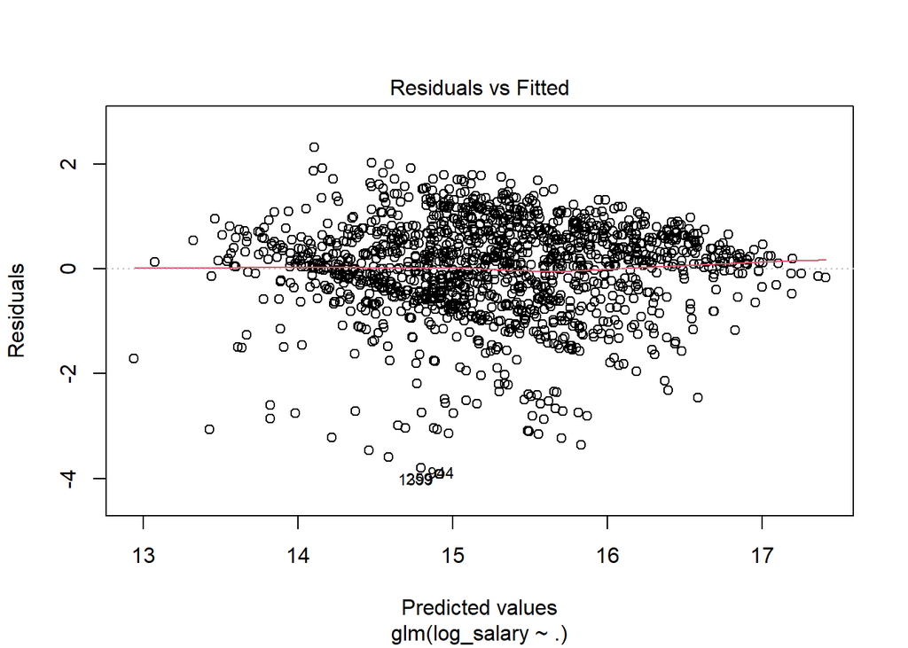

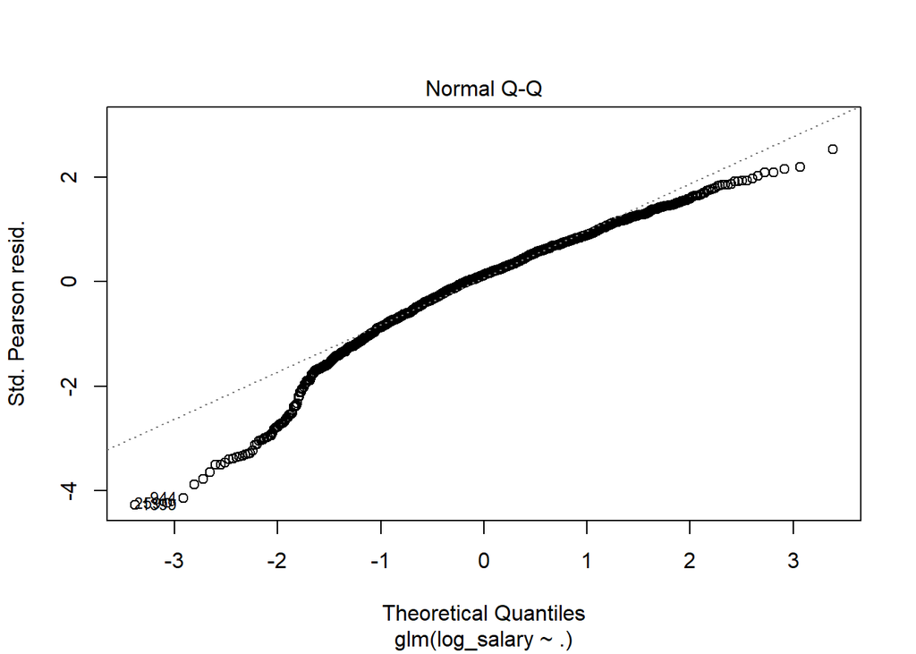

```r
plot(ols.share, which = c(1, 2))
```

## Should We Remove the insignificant variables?

We can see that some of the predictors in the model are not significant. But should we removed them? Or does controlling for them improve the model? Let’s find out using CV.

```r
bdata.step %>%
  select(-draft_pick, -Age, -G, -BLK) ->
bdata.step2

ols.step2 <- glm(log_salary ~ ., data = bdata.step2)

lm.step <- lm(log_salary ~ ., data = bdata.step)
lm.step2 <- lm(log_salary ~ ., data = bdata.step2)


anova(lm.step2, lm.step)
```

```
## Analysis of Variance Table
##
## Model 1: log_salary ~ career_G + career_PTS + height + GS + MP + FG +
##     FGA + THREEP + THREEP_P + FT + FT_P + STL + TOV + PF + PTS +
##     year + career_FG3_P + career_FG_P + career_FT_P
## Model 2: log_salary ~ career_G + career_PTS + draft_pick + height + Age +
##     G + GS + MP + FG + FGA + THREEP + THREEP_P + FT + FT_P +
##     STL + BLK + TOV + PF + PTS + year + career_FG3_P + career_FG_P +
##     career_FT_P
##   Res.Df    RSS Df Sum of Sq      F  Pr(>F)
## 1   1384 1163.0
## 2   1380 1151.7  4    11.386 3.4109 0.00874 **
## ---
## Signif. codes:  0 '***' 0.001 '**' 0.01 '*' 0.05 '.' 0.1 ' ' 1
```

```r
cv.ols.step2 <- cv.glm(bdata.step2, ols.step2)

cbind("Step" = cv.step$delta, "Step2" = cv.ols.step2$delta)
```

```
##           Step     Step2
## [1,] 0.8507914 0.8539373
## [2,] 0.8507804 0.8539282
```

The ANOVA test gives us significant results, this indicates using the larger feature set.

Additionally, the larger data set cross validates better. We will keep the insignificant variables in.

# Final Model

```r
summary(ols.step)
```

```
##
## Call:
## glm(formula = log_salary ~ ., data = bdata.step)
##
## Deviance Residuals:
##     Min       1Q   Median       3Q      Max
## -3.9223  -0.4693   0.1186   0.5955   2.2148
##
## Coefficients:
##                Estimate Std. Error t value Pr(>|t|)
## (Intercept)  -3.459e+02  5.214e+01  -6.634 4.68e-11 ***
## career_G      1.465e-03  2.489e-04   5.887 4.94e-09 ***
## career_PTS   -2.754e-02  1.209e-02  -2.278 0.022898 *
## draft_pick   -3.218e-03  2.024e-03  -1.590 0.112138
## height        4.787e-02  1.086e-02   4.410 1.12e-05 ***
## Age          -2.500e-02  1.598e-02  -1.564 0.118041
## G             2.344e-03  1.455e-03   1.612 0.107256
## GS            5.424e-03  1.574e-03   3.446 0.000587 ***
## MP            2.501e-02  9.550e-03   2.619 0.008914 **
## FG            1.271e+00  6.511e-01   1.952 0.051098 .
## FGA           1.264e-01  4.577e-02   2.761 0.005831 **
## THREEP        8.123e-01  3.248e-01   2.501 0.012488 *
## THREEP_P     -1.423e+00  3.624e-01  -3.927 9.03e-05 ***
## FT            7.753e-01  3.254e-01   2.383 0.017327 *
## FT_P         -7.638e-01  3.284e-01  -2.326 0.020175 *
## STL           2.616e-01  9.239e-02   2.831 0.004701 **
## BLK           1.454e-01  9.721e-02   1.495 0.135051
## TOV           2.084e-01  6.902e-02   3.020 0.002576 **
## PF           -2.111e-01  5.720e-02  -3.690 0.000233 ***
## PTS          -7.425e-01  3.247e-01  -2.287 0.022354 *
## year          1.756e-01  2.588e-02   6.784 1.73e-11 ***
## career_FG3_P  2.746e-02  5.455e-03   5.034 5.43e-07 ***
## career_FG_P   2.699e-02  8.501e-03   3.175 0.001532 **
## career_FT_P   1.286e-02  5.049e-03   2.548 0.010948 *
## ---
## Signif. codes:  0 '***' 0.001 '**' 0.01 '*' 0.05 '.' 0.1 ' ' 1
##
## (Dispersion parameter for gaussian family taken to be 0.8345391)
##
##     Null deviance: 2028.8  on 1403  degrees of freedom
## Residual deviance: 1151.7  on 1380  degrees of freedom
## AIC: 3756.2
##
## Number of Fisher Scoring iterations: 2
```

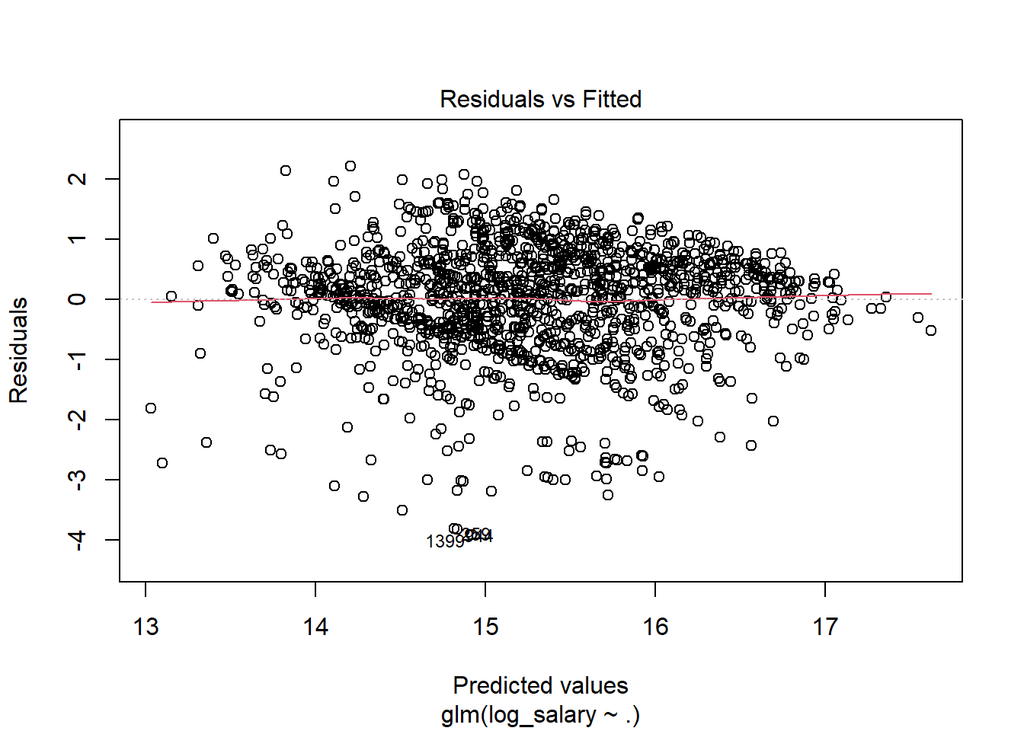

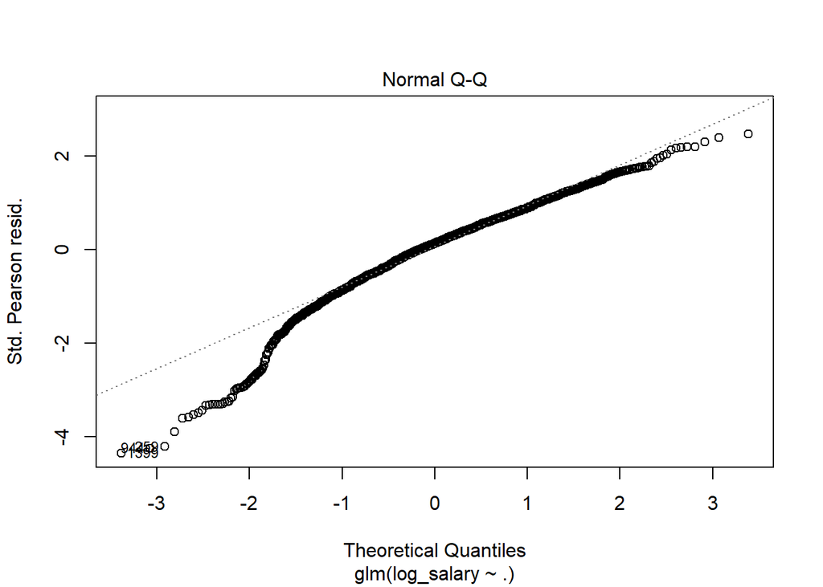

```r
plot(ols.step, which = c(1,2))
```